## Introduction

In this project our aim is to inspect 5 different time series classification datasets and evaluate them with time series representation and classification methods. We will use nearest neighbor approach. We will use some of the results from classification methods and then use them to find the accuracies on test datas.

```r
library(data.table,quietly = TRUE,warn.conflicts = FALSE)
library(ggplot2,quietly = TRUE,warn.conflicts = FALSE)
library(repr,quietly = TRUE,warn.conflicts = FALSE)
library(rpart,quietly = TRUE,warn.conflicts = FALSE)
library(rattle,quietly = TRUE,warn.conflicts = FALSE)
library(TSrepr,quietly = TRUE,warn.conflicts = FALSE)
library(zoo,quietly = TRUE,warn.conflicts = FALSE)
library(genlasso,quietly = TRUE,warn.conflicts = FALSE)
library(e1071,quietly = TRUE,warn.conflicts = FALSE)
library(MLmetrics,quietly = TRUE,warn.conflicts = FALSE)
library(shiny,quietly = TRUE,warn.conflicts = FALSE)
library(manipulateWidget,quietly = TRUE,warn.conflicts = FALSE)
library(TSclust,quietly = TRUE,warn.conflicts = FALSE)
library(plyr,quietly = TRUE,warn.conflicts = FALSE)
library(TunePareto,quietly = TRUE,warn.conflicts = FALSE)
library(dtw,quietly = TRUE,warn.conflicts = FALSE)
library(TSdist,quietly = TRUE,warn.conflicts = FALSE)
library(caret,quietly = TRUE,warn.conflicts = FALSE)
```

## Classification function

We will use the classification function to find the accuracy of our work later.

```r
nn_classify_cv=function(dist_matrix,train_class,test_indices,k=1){

    test_distances_to_train=dist_matrix[test_indices,]
    test_distances_to_train=test_distances_to_train[,-test_indices]
    train_class=train_class[-test_indices]
    ordered_indices=apply(test_distances_to_train,1,order)
    if(k==1){
        nearest_class=as.numeric(trainclass[as.numeric(ordered_indices[1,])])
        nearest_class=data.table(id=test_indices,nearest_class)
    } else {
        nearest_class=apply(ordered_indices[1:k,],2,function(x) {trainclass[x]})
        nearest_class=data.table(id=test_indices,t(nearest_class))
    }
    long_nn_class=melt(nearest_class,'id')
    class_counts=long_nn_class[,.N,list(id,value)]
    class_counts[,predicted_prob:=N/k]
    wide_class_prob_predictions=dcast(class_counts,id~value,value.var='predicted_prob')
    wide_class_prob_predictions[is.na(wide_class_prob_predictions)]=0
    class_predictions=class_counts[,list(predicted=value[which.max(N)]),by=list(id)]
    return(list(prediction=class_predictions,prob_estimates=wide_class_prob_predictions))

}
```

## 1st Dataset Plane

## Data Manipulation

We read our data with fread function. We do some data manipulation to understand the data easier.

```r
plane_train=fread("D:/Boğaziçi/İe48b/Univariate_arff/Plane/Plane_TRAIN.txt")
plane_test=fread("D:/Boğaziçi/İe48b/Univariate_arff/Plane/Plane_TEST.txt")
head(plane_train,10)
```

```
##     V1       V2        V3        V4        V5        V6          V7         V8
##  1:  1 2.483940 2.2762865 2.0675157 1.9218926 1.7187752  1.50842850  1.3006752
##  2:  4 2.603320 2.3406991 2.0822848 1.8256242 1.5677057  1.31220300  1.0571948
##  3:  6 2.757321 2.5766667 2.3633233 2.1515785 1.9402183  1.72942750  1.5194285
##  4:  5 0.916063 0.7201453 0.5224446 0.3258262 0.1343814 -0.05401188 -0.2355249
##  5:  2 2.656142 2.3881447 2.1185954 1.8496769 1.5765789  1.31016860  1.1096989
##  6:  6 2.716798 2.5208585 2.3196204 2.1164411 1.9136371  1.71124980  1.5093279
##  7:  6 2.682277 2.4972437 2.2947108 2.0925379 1.8906732  1.68964710  1.4879267
##  8:  1 2.483831 2.2688158 2.0626299 1.8713282 1.6610729  1.46083230  1.2592238
##  9:  2 2.546714 2.2531057 1.9658541 1.6824847 1.4057430  1.12852750  0.9886699
## 10:  6 2.737010 2.5098085 2.2778408 2.0491548 1.8199174  1.59515080  1.3686333
##             V9        V10        V11         V12        V13         V14
##  1:  1.0902862  0.8827328  0.6723009  0.46338263  0.2545249  0.04573843
##  2:  0.8017157  0.5466832  0.2918485  0.03662012 -0.0761458 -0.07734542
##  3:  1.3095473  1.1002525  0.8914930  0.68316216  0.4828424  0.29863458
```

[output cut: 249 more lines]

```r
head(plane_test,10)
```

```
##     V1        V2        V3        V4        V5        V6           V7
##  1:  6 2.6843023 2.4537677 2.2303844 2.0111692 1.7941182  1.577387000
##  2:  1 2.4726101 2.2356114 2.0139566 1.8142436 1.5865378  1.366993800
##  3:  3 2.6121085 2.4104065 2.2095360 2.0090774 1.8084274  1.607661700
##  4:  5 0.9186073 0.7087953 0.5209432 0.3422712 0.1677084 -0.005989314
##  5:  2 2.5832793 2.3290317 2.0775394 1.8262124 1.5757194  1.325423600
##  6:  4 2.6058801 2.3382851 2.0739915 1.8118079 1.5505170  1.290509000
##  7:  3 2.7025634 2.4829514 2.2705805 2.0609709 1.8526615  1.639991300
##  8:  2 2.5632570 2.2664206 1.9701469 1.6757340 1.4073147  1.127490900
##  9:  4 2.5384840 2.2267076 1.9324712 1.6511857 1.3854418  1.117611500
## 10:  3 2.6199846 2.3957083 2.1618463 1.9352692 1.7215089  1.531812500
##             V8         V9        V10         V11          V12         V13
##  1:  1.3596800  1.1444859  0.9271364  0.71290350  0.513699800  0.34196826
##  2:  1.1509717  0.9424066  0.7263061  0.51036635  0.294617610  0.08288335
##  3:  1.4103988  1.2089326  1.0075043  0.80468669  0.606389750  0.40519467
```

[output cut: 249 more lines]

```r
setnames(plane_train,"V1","class")
plane_train=plane_train[order(class)]
plane_train[,class:=as.character(class)]
plane_train[,id:=1:.N]
long_plane_train=melt(plane_train,id.vars=c('id','class'))
long_plane_train[,time:=as.numeric(gsub("\\D", "", variable))]
long_plane_train=long_plane_train[,list(id,class,time,value)]
long_plane_train=long_plane_train[order(id,time)]
head(long_plane_train,20)
```

```
##     id class time       value
##  1:  1     1    2  2.48393970
##  2:  1     1    3  2.27628650
##  3:  1     1    4  2.06751570
##  4:  1     1    5  1.92189260
##  5:  1     1    6  1.71877520
##  6:  1     1    7  1.50842850
##  7:  1     1    8  1.30067520
##  8:  1     1    9  1.09028620
##  9:  1     1   10  0.88273283
## 10:  1     1   11  0.67230088
## 11:  1     1   12  0.46338263
## 12:  1     1   13  0.25452493
## 13:  1     1   14  0.04573843
## 14:  1     1   15 -0.15618851
## 15:  1     1   16 -0.20898526
## 16:  1     1   17 -0.39491294
## 17:  1     1   18 -0.59416173
## 18:  1     1   19 -0.79717148
## 19:  1     1   20 -0.97459659
## 20:  1     1   21 -1.12816260
```

## Visualization

We use some plots to see our data and have some idea about the patterns.

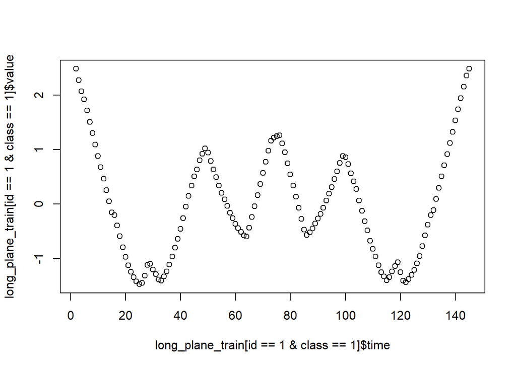

```r
plot(x=long_plane_train[id==1 & class==1]$time,y=long_plane_train[id==1 &  class==1]$value)
```

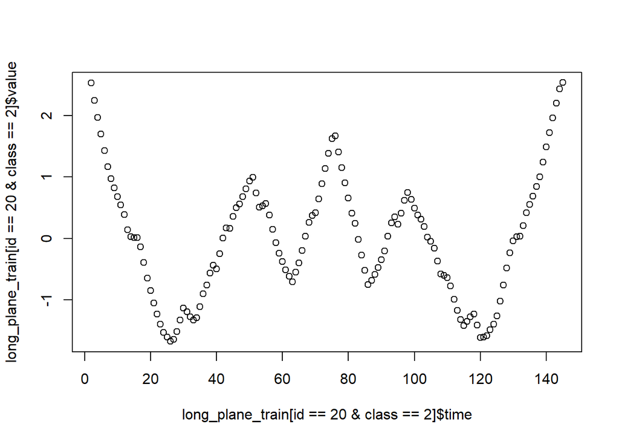

```r
plot(x=long_plane_train[id==20 & class==2]$time,y=long_plane_train[id==20 &  class==2]$value)
```

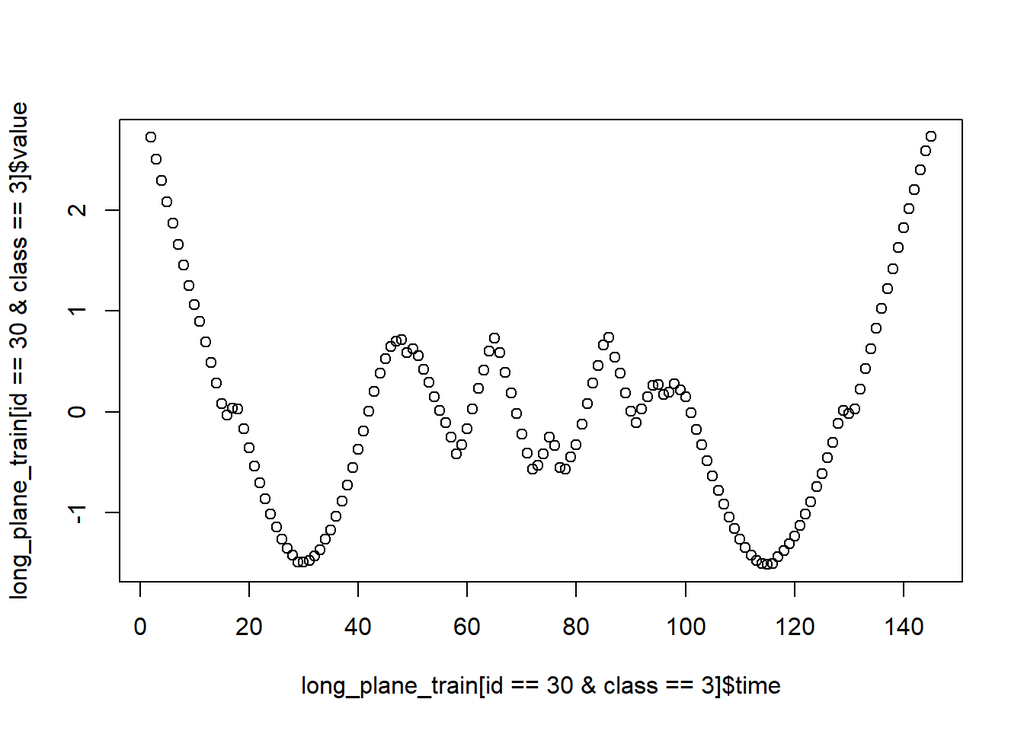

```r
plot(x=long_plane_train[id==30 & class==3]$time,y=long_plane_train[id==30 &  class==3]$value)
```

## Fused Lasso Approach

We will use fused lasso approach for one of our classification methods.

```r
train_row_1=nrow(plane_train)
test_row_1=nrow(plane_test)
f_res=vector("list",train_row_1)
for(i in 1:train_row_1){
      dt_1=long_plane_train[id==i]
      dt_1=as.matrix(dt_1[,4],rownames=FALSE)
      f_lasso=trendfilter(dt_1, ord=0)
      cv=cv.trendfilter(f_lasso)
      f_res[[i]]=predict.genlasso(f_lasso,cv$lambda.min)
}
```

[output not shown]

[output cut: 50 more lines]

[output not shown]

```r
fused_lasso_dt=vector('list',train_row_1)
for(i in seq(1:train_row_1)){
      fused_lasso_dt[[i]]=as.data.table(t(f_res[[i]]$fit))
}
lasso_fit=rbindlist(fused_lasso_dt)
head(lasso_fit,20)
```

```
##           V1       V2       V3       V4       V5       V6        V7        V8
##  1: 2.477515 2.276286 2.067516 1.921893 1.718775 1.508428 1.3006752 1.0902862
##  2: 2.480112 2.268816 2.062630 1.871328 1.661073 1.460832 1.2592238 1.0642268
##  3: 2.483075 2.285890 2.092948 1.901565 1.711442 1.520270 1.3284437 1.1393131
##  4: 2.537109 2.344460 2.129988 1.920682 1.701969 1.493056 1.2842867 1.0800852
##  5: 2.441123 2.322454 2.133778 1.943460 1.753229 1.563099 1.3752474 1.1877922
##  6: 2.435770 2.248813 2.058446 1.868393 1.678090 1.489388 1.2995706 1.1110215
##  7: 2.428410 2.227188 2.028776 1.833446 1.632725 1.437723 1.2403784 1.0604799
##  8: 2.321766 2.129842 1.938807 1.747972 1.607164 1.458699 1.3995604 1.3348357
##  9: 2.360142 2.170287 1.982475 1.795503 1.607084 1.419989 1.2324846 1.0462894
## 10: 2.451072 2.248850 2.051742 1.855799 1.659702 1.552139 1.3569138 1.1631714
## 11: 2.364011 2.192751 2.019496 1.838067 1.656650 1.475247 1.2969108 1.1198635
## 12: 2.409474 2.218512 2.045046 1.854159 1.662955 1.473841 1.2827560 1.0924231
## 13: 2.440606 2.238800 2.039824 1.843555 1.647799 1.450868 1.2540363 1.0610550
## 14: 2.452365 2.343995 2.166347 1.984213 1.797266 1.615589 1.4289366 1.2406365
```

[output cut: 468 more lines]

## Piecewise Approximation Approach

We will use piecewise approximation approach for one of our classification methods.

```r
train_row_1=nrow(plane_train)
test_row_1=nrow(plane_test)
seg_len_1=5
long_plane_train=long_plane_train[order(id,time)]
paa_res=vector('list',train_row_1)
for (i in 1:train_row_1){
      data_ts=long_plane_train[id==i]$value
      paa_rep=repr_paa(data_ts,seg_len_1,meanC)
      paa_res[[i]]=paa_rep
}
paa_list=vector('list', train_row_1)
for (i in 1:train_row_1) {
      paa_list[[i]]=as.data.table(t(paa_res[[i]]))
}
paa_seg_5=rbindlist(paa_list)
head(paa_seg_5,20)
```

```
##           V1        V2         V3         V4         V5        V6        V7
##  1: 2.093682 1.0908847 0.07969444 -0.7778011 -1.3914851 -1.209109 -1.299063
##  2: 2.069536 1.0638230 0.10236793 -0.6828944 -1.2752839 -1.031302 -1.154401
##  3: 2.095242 1.1393722 0.18981037 -0.6223103 -1.2817415 -1.219765 -1.155710
##  4: 2.127197 1.0784346 0.07469711 -0.7192320 -1.2622838 -1.033328 -1.143215
##  5: 2.120554 1.1861544 0.23433968 -0.5945498 -1.2591767 -1.243950 -1.241009
##  6: 2.058689 1.1103595 0.16107181 -0.6351256 -1.2811529 -1.181506 -1.246511
##  7: 2.030229 1.0570376 0.09782601 -0.6900804 -1.3066413 -1.089446 -1.176079
##  8: 1.949232 1.2582289 0.38335503 -0.4916708 -1.2085413 -1.431435 -1.219177
##  9: 1.983332 1.0463564 0.14601987 -0.2986920 -0.8783407 -1.454743 -1.212189
## 10: 2.053672 1.1627672 0.19007711 -0.6362939 -1.3033533 -1.185280 -1.230408
## 11: 2.014285 1.1170763 0.22153770 -0.5702999 -1.2307081 -1.478646 -1.149855
## 12: 2.038168 1.0925130 0.13957301 -0.6799342 -1.3215468 -1.223812 -1.231032
## 13: 2.042222 1.0682072 0.10967232 -0.6863150 -1.3090784 -1.121685 -1.205803
## 14: 2.149987 1.2400104 0.28927201 -0.5251411 -1.2262049 -1.436152 -1.206801
```

[output cut: 90 more lines]

```r
seg_len_2=10
long_plane_train=long_plane_train[order(id,time)]
paa_res=vector('list',train_row_1)
for (i in 1:train_row_1){
      data_ts=long_plane_train[id==i]$value
      paa_rep=repr_paa(data_ts,seg_len_2,meanC)
      paa_res[[i]]=paa_rep
}
paa_list=vector('list', train_row_1)
for (i in 1:train_row_1) {
      paa_list[[i]]=as.data.table(t(paa_res[[i]]))
}
paa_seg_10=rbindlist(paa_list)
head(paa_seg_10,20)
```

```
##           V1          V2        V3         V4         V5           V6
##  1: 1.592283 -0.34905331 -1.300297 -0.9625546  0.6034822  0.047204810
##  2: 1.566679 -0.29026322 -1.153293 -0.8688433  0.4851141 -0.235976644
##  3: 1.617307 -0.21624998 -1.250753 -1.0877429  0.1756470  0.031349928
##  4: 1.602816 -0.32226746 -1.147806 -0.7995090  0.4625890 -0.367488982
##  5: 1.653354 -0.18010505 -1.251564 -1.0878133  0.2090517 -0.036416059
##  6: 1.584524 -0.23702687 -1.231329 -0.9537855  0.3086453 -0.289148174
##  7: 1.543633 -0.29612721 -1.198044 -0.9173516  0.4436218 -0.218027318
##  8: 1.603730 -0.05415789 -1.319988 -1.1655947  0.1041073  0.230003403
##  9: 1.514844 -0.07633608 -1.166542 -1.2002287 -0.7185223  0.487496541
## 10: 1.608220 -0.22310841 -1.244317 -1.0322030  0.3374043 -0.038989108
## 11: 1.565681 -0.17438109 -1.354677 -1.1655119 -0.5059910  0.497350714
## 12: 1.565340 -0.27018059 -1.272679 -1.0534745  0.2994253 -0.032577865
## 13: 1.555215 -0.28832135 -1.215381 -0.9096700  0.4621206 -0.200247823
## 14: 1.694999 -0.11793455 -1.331179 -1.2150208 -0.2268575  0.302826485
```

[output cut: 48 more lines]

```r
seg_len_3=20
long_plane_train=long_plane_train[order(id,time)]
paa_res=vector('list',train_row_1)
for (i in 1:train_row_1){
      data_ts=long_plane_train[id==i]$value
      paa_rep=repr_paa(data_ts,seg_len_3,meanC)
      paa_res[[i]]=paa_rep
}
paa_list=vector('list', train_row_1)
for (i in 1:train_row_1) {
      paa_list[[i]]=as.data.table(t(paa_res[[i]]))
}
paa_seg_20=rbindlist(paa_list)
head(paa_seg_20,20)
```

```
##            V1         V2           V3         V4           V5         V6
##  1: 0.6216150 -1.1314259  0.325343525 0.44902714  0.084275588 -0.7348635
##  2: 0.6382080 -1.0110681  0.124568726 0.79134896 -0.132223862 -1.0282464
##  3: 0.7005284 -1.1692481  0.103498471 0.64361206 -0.022577603 -0.8216781
##  4: 0.6402743 -0.9736576  0.047550005 0.78527801 -0.134296264 -0.9437716
##  5: 0.7366245 -1.1696884  0.086317801 0.72661801  0.030492890 -0.8650479
##  6: 0.6737488 -1.0925574  0.009748560 0.85337928  0.006479942 -0.9681325
##  7: 0.6237530 -1.0576975  0.112797217 0.81047311 -0.122477023 -0.9994557
##  8: 0.7747862 -1.2427914  0.167055352 0.68759889  0.124436902 -0.9235394
##  9: 0.7192540 -1.1833853 -0.115512888 0.23812236  0.590422199 -0.7379816
## 10: 0.6925556 -1.1382599  0.149207618 0.73937774 -0.029262780 -0.9122938
## 11: 0.6956499 -1.2600945 -0.004320125 0.42539042  0.284599283 -0.6597725
## 12: 0.6475799 -1.1630769  0.133423702 0.76744429  0.021896930 -0.9399893
## 13: 0.6334466 -1.0625257  0.130936369 0.79865899 -0.018305555 -1.0361125
## 14: 0.7885321 -1.2730997  0.037984507 0.52382362  0.110183245 -0.5969024
```

[output cut: 27 more lines]

[figure not shown]

```r
plot(x=long_plane_train[id==1 & class==1]$time,y=long_plane_train[id==1 & class==1]$paa_seg_5)
```

[figure not shown]

```r
plot(x=long_plane_train[id==20 & class==2]$time,y=long_plane_train[id==20 & class==2]$paa_seg_10)
```

[figure not shown]

```r
plot(x=long_plane_train[id==30 & class==3]$time,y=long_plane_train[id==30 & class==3]$paa_seg_20)
```

```r
plane_train_raw=data.frame()
for(i in 1:length(unique(long_plane_train$id))){
    plane_train_raw=rbind(plane_train_raw,t(as.data.frame(long_plane_train[id==i]$value)))
}
row.names(plane_train_raw)=NULL
```

## Raw time series distances

```r
dataset='Plane'
main_path=sprintf('D:/Boğaziçi/İe48b/Univariate_arff/Plane/ClassificationData')
dist_path=sprintf('D:/Boğaziçi/İe48b/Univariate_arff/Plane/ClassificationData/distances')
large_number=10000

dist_euc_1=as.matrix(dist(plane_train_raw))
diag(dist_euc_1)=large_number
fwrite(dist_euc_1,sprintf('%s/_euc_dist_1.csv',dist_path),col.names=F)
```

```
## x being coerced from class: matrix to data.table
```

```r
dist_dtw_1=as.matrix(dtwDist(plane_train_raw))
diag(dist_dtw_1)=large_number
fwrite(dist_dtw_1,sprintf('%s/_dtw_raw_dist_1.csv',dist_path),col.names=F)
```

```
## x being coerced from class: matrix to data.table
```

```r
dist_lcss_1=TSDatabaseDistances(plane_train_raw,distance='lcss',epsilon=0.05)
dist_lcss_1=as.matrix(dist_lcss_1)
diag(dist_lcss_1)=large_number
fwrite(dist_lcss_1,sprintf('%s/_lcss_dist_1.csv',dist_path),col.names=F)
```

```
## x being coerced from class: matrix to data.table
```

```r
dist_erp_1=TSDatabaseDistances(plane_train_raw,distance='erp',g=0.5)
dist_erp_1=as.matrix(dist_erp_1)
diag(dist_erp_1)=large_number
fwrite(dist_erp_1,sprintf('%s/_erp_dist_1.csv', dist_path),col.names=F)
```

```
## x being coerced from class: matrix to data.table
```

## Fused Lasso Distances

```r
dist_euc_lasso=as.matrix(dist(lasso_fit))
diag(dist_euc_lasso)=large_number
fwrite(dist_euc_lasso,sprintf('%s_euc_lasso_dist.csv',dist_path),col.names=F)
```

```
## x being coerced from class: matrix to data.table
```

```r
dist_dtw_2=as.matrix(dtwDist(lasso_fit))
diag(dist_dtw_2)=large_number
fwrite(dist_dtw_2,sprintf('%s/_dtw_raw_dist_2.csv',dist_path),col.names=F)
```

```
## x being coerced from class: matrix to data.table
```

```r
dist_lcss_2=TSDatabaseDistances(lasso_fit,distance='lcss',epsilon=0.07)
dist_lcss_2=as.matrix(dist_lcss_2)
diag(dist_lcss_2)=large_number
fwrite(dist_lcss_2,sprintf('%s/_lcss_dist_2.csv',dist_path),col.names=F)
```

```
## x being coerced from class: matrix to data.table
```

```r
dist_erp_2=TSDatabaseDistances(lasso_fit,distance='erp',g=0.7)
dist_erp_2=as.matrix(dist_erp_2)
diag(dist_erp_2)=large_number
fwrite(dist_erp_2,sprintf('%s/_erp_dist_2.csv', dist_path),col.names=F)
```

```
## x being coerced from class: matrix to data.table
```

## Piecewise Approximation Approach distances

```r
dist_euc_paa=as.matrix(dist(paa_seg_5))
diag(dist_euc_paa)=large_number
fwrite(dist_euc_paa,sprintf('%s/_euc_raw_paa_segment_5_dist.csv',dist_path),col.names=F)
```

```
## x being coerced from class: matrix to data.table
```

```r
dist_euc_3=as.matrix(dist(paa_seg_5))
diag(dist_euc_3)=large_number
fwrite(dist_euc_3,sprintf('%s/_euc_dist_3.csv',dist_path),col.names=F)
```

```
## x being coerced from class: matrix to data.table
```

```r
dist_dtw_3=as.matrix(dtwDist(paa_seg_5))
diag(dist_dtw_3)=large_number
fwrite(dist_dtw_3,sprintf('%s/_dtw_raw_dist_3.csv',dist_path),col.names=F)
```

```
## x being coerced from class: matrix to data.table
```

```r
dist_lcss_3=TSDatabaseDistances(paa_seg_5,distance='lcss',epsilon=0.09)
dist_lcss_3=as.matrix(dist_lcss_3)
diag(dist_lcss_3)=large_number
fwrite(dist_lcss_3,sprintf('%s/_lcss_dist_3.csv',dist_path),col.names=F)
```

```
## x being coerced from class: matrix to data.table
```

```r
dist_erp_3=TSDatabaseDistances(paa_seg_5,distance='erp',g=0.9)
dist_erp_3=as.matrix(dist_erp_3)
diag(dist_erp_3)=large_number
fwrite(dist_erp_3,sprintf('%s/_erp_dist_3.csv', dist_path),col.names=F)
```

```
## x being coerced from class: matrix to data.table
```

```r
set.seed(213)
nof_rep=10
n_fold=10
trainclass=c()
for(i in 1:length(unique(long_plane_train$id))){
    trainclass=c(trainclass,unique(long_plane_train[id==i,class]))
}
cv_indices=generateCVRuns(trainclass,ntimes=nof_rep,nfold=n_fold,leaveOneOut=FALSE,stratified=TRUE)
str(cv_indices)
```

```
## List of 10
##  $ Run  1 :List of 10
##   ..$ Fold  1 : int [1:11] 8 14 26 33 43 40 60 70 73 102 ...
##   ..$ Fold  2 : int [1:11] 12 5 18 32 50 53 59 75 68 92 ...
##   ..$ Fold  3 : int [1:11] 9 4 21 38 42 39 65 85 69 103 ...
##   ..$ Fold  4 : int [1:11] 1 6 19 36 51 52 63 71 84 89 ...
##   ..$ Fold  5 : int [1:11] 7 10 28 35 44 61 66 79 72 104 ...
##   ..$ Fold  6 : int [1:10] 2 17 29 34 54 62 67 74 87 86
##   ..$ Fold  7 : int [1:10] 3 22 16 37 41 58 55 81 101 90
##   ..$ Fold  8 : int [1:10] 15 24 27 30 49 64 76 77 88 95
##   ..$ Fold  9 : int [1:10] 13 25 23 46 45 56 80 83 105 98
##   ..$ Fold  10: int [1:10] 11 20 31 48 47 57 78 82 91 97
##  $ Run  2 :List of 10
##   ..$ Fold  1 : int [1:11] 3 8 26 36 47 51 58 82 75 91 ...
##   ..$ Fold  2 : int [1:11] 4 14 24 37 52 53 62 74 85 87 ...
##   ..$ Fold  3 : int [1:11] 13 1 16 33 48 49 64 69 81 90 ...
##   ..$ Fold  4 : int [1:11] 2 6 23 34 54 39 60 79 80 95 ...
##   ..$ Fold  5 : int [1:11] 5 10 25 32 44 65 57 77 68 88 ...
##   ..$ Fold  6 : int [1:10] 9 19 22 35 41 67 59 71 89 105
##   ..$ Fold  7 : int [1:10] 15 21 18 30 45 56 66 84 97 101
##   ..$ Fold  8 : int [1:10] 12 27 28 38 46 63 72 76 96 102
##   ..$ Fold  9 : int [1:10] 7 29 17 40 50 61 73 70 98 94
##   ..$ Fold  10: int [1:10] 11 20 31 43 42 55 78 83 86 93
##  $ Run  3 :List of 10
##   ..$ Fold  1 : int [1:11] 6 15 19 37 46 39 65 77 71 87 ...
##   ..$ Fold  2 : int [1:11] 14 3 22 38 52 48 62 68 75 104 ...
##   ..$ Fold  3 : int [1:11] 4 10 25 34 44 41 59 84 69 105 ...
##   ..$ Fold  4 : int [1:11] 5 7 21 32 43 49 55 79 82 99 ...
##   ..$ Fold  5 : int [1:11] 12 11 27 31 40 66 63 74 81 101 ...
##   ..$ Fold  6 : int [1:10] 2 17 24 36 42 67 61 70 88 97
##   ..$ Fold  7 : int [1:10] 8 18 23 35 51 64 57 73 91 86
##   ..$ Fold  8 : int [1:10] 13 20 26 33 45 56 78 80 96 103
##   ..$ Fold  9 : int [1:10] 1 29 16 54 47 60 85 83 95 92
##   ..$ Fold  10: int [1:10] 9 28 30 50 53 58 72 76 100 94
##  $ Run  4 :List of 10
##   ..$ Fold  1 : int [1:11] 3 4 25 32 49 43 61 69 74 100 ...
##   ..$ Fold  2 : int [1:11] 2 11 27 37 46 50 59 75 71 98 ...
##   ..$ Fold  3 : int [1:11] 8 14 28 38 53 44 67 77 73 89 ...
##   ..$ Fold  4 : int [1:11] 10 9 26 33 54 45 57 80 85 93 ...
##   ..$ Fold  5 : int [1:11] 15 7 17 34 48 65 63 79 70 97 ...
```

[output cut: 56 more lines]

```
##   ..$ Fold  7 : int [1:10] 13 27 28 30 49 56 60 81 99 94
##   ..$ Fold  8 : int [1:10] 4 23 21 33 50 67 79 77 101 96
##   ..$ Fold  9 : int [1:10] 8 24 29 47 41 58 83 74 97 88
##   ..$ Fold  10: int [1:10] 15 25 31 46 53 66 75 76 89 92
##  $ Run  10:List of 10
##   ..$ Fold  1 : int [1:11] 6 15 24 32 50 41 60 77 78 92 ...
##   ..$ Fold  2 : int [1:11] 5 11 28 30 47 53 67 71 76 103 ...
##   ..$ Fold  3 : int [1:11] 14 8 26 33 52 49 64 69 70 105 ...
##   ..$ Fold  4 : int [1:11] 4 7 23 37 48 44 56 68 73 88 ...
##   ..$ Fold  5 : int [1:11] 2 12 29 38 39 63 57 84 83 102 ...
##   ..$ Fold  6 : int [1:10] 1 27 16 31 45 66 65 72 101 104
##   ..$ Fold  7 : int [1:10] 13 22 19 34 40 59 61 85 99 95
##   ..$ Fold  8 : int [1:10] 9 25 21 36 46 55 80 81 89 98
##   ..$ Fold  9 : int [1:10] 10 20 17 51 42 58 82 79 90 93
##   ..$ Fold  10: int [1:10] 3 18 35 43 54 62 74 75 96 86
```

```r
dist_folder=sprintf('D:/Boğaziçi/İe48b/Univariate_arff/Plane/ClassificationData/distances')
dist_files=list.files(dist_folder, full.names=T)
```

```r
k_levels=c(1,3,5)
approach_file=list.files(dist_folder)
result=vector('list',length(dist_files)*nof_rep*n_fold*length(k_levels))
iter=1
for(m in 1:length(dist_files)){ #
    dist_mat=as.matrix(fread(dist_files[m],header=FALSE))
    for(i in 1:nof_rep){
        this_fold=cv_indices[[i]]
        for(j in 1:n_fold){
            test_indices=this_fold[[j]]
            for(k in 1:length(k_levels)){
                current_k=k_levels[k]
                current_fold=nn_classify_cv(dist_mat,trainclass,test_indices,k=current_k)
                accuracy=sum(trainclass[test_indices]==current_fold$prediction$predicted)/length(test_indices)
                tmp=data.table(approach=approach_file[m],repid=i,foldid=j,
                               k=current_k,acc=accuracy)
                result[[iter]]=tmp
                iter=iter+1

            }

        }

    }

}
```

```r
final_results=rbindlist(result)
summarized_results=final_results[,list(avg_acc=mean(acc),sdev_acc=sd(acc),result_count=.N),by=list(approach,k)]
summarized_results[order(-avg_acc)]
```

```
##                             approach k    avg_acc   sdev_acc result_count
##  1:                  _erp_dist_1.csv 3 0.82318182 0.11644464          100
##  2:                  _erp_dist_2.csv 3 0.82154545 0.11648965          100
##  3:                  _erp_dist_2.csv 5 0.81463636 0.10929652          100
##  4:                  _erp_dist_1.csv 5 0.81227273 0.10408932          100
##  5: _euc_raw_paa_segment_20_dist.csv 5 0.78627273 0.12157312          100
##  6:                  _erp_dist_3.csv 3 0.76645455 0.12424373          100
##  7:              _dtw_raw_dist_2.csv 5 0.75836364 0.10407171          100
##  8: _euc_raw_paa_segment_10_dist.csv 5 0.75463636 0.12459129          100
##  9:              _dtw_raw_dist_3.csv 3 0.75300000 0.13217664          100
## 10:              _dtw_raw_dist_3.csv 5 0.74981818 0.13024523          100
## 11:              _dtw_raw_dist_1.csv 5 0.74890909 0.10979859          100
## 12: _euc_raw_paa_segment_10_dist.csv 3 0.74618182 0.14188504          100
## 13: _euc_raw_paa_segment_20_dist.csv 3 0.74227273 0.11920777          100
## 14:                  _euc_dist_3.csv 3 0.74009091 0.13998614          100
```

[output cut: 29 more lines]

```r
overall_results_summary=final_results[,list(avg_acc=mean(acc),sdev_acc=sd(acc),result_count=.N),by=list(approach,k)]
overall_results_summary[which.max(overall_results_summary$avg_acc),]
```

```
##           approach k   avg_acc  sdev_acc result_count
## 1: _erp_dist_1.csv 3 0.8231818 0.1164446          100
```

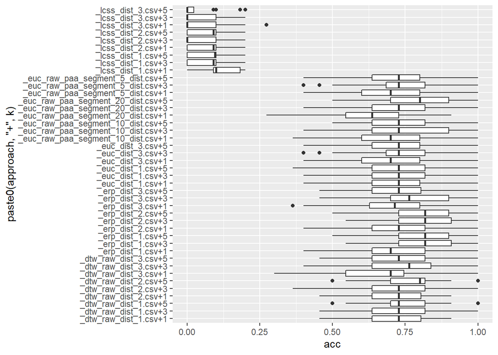

```r
ggplot(final_results,aes(x=paste0(approach,'+',k),y=acc))+geom_boxplot()+coord_flip()
```

Best result is from k=3, erp distance 1 value which is 0.82. It is from raw dataset.

## 2nd Dataset Trace

## Data Manipulation

We read our data with fread function. We do some data manipulation to understand the data easier.

```r
trace_train=fread("D:/Boğaziçi/İe48b/Univariate_arff/Trace/Trace_TRAIN.txt")
trace_test=fread("D:/Boğaziçi/İe48b/Univariate_arff/Trace/Trace_TEST.txt")
head(trace_train,10)
```

```
##     V1         V2         V3         V4         V5         V6         V7
##  1:  1  0.5440704  0.6578630  0.6112391  0.5454131  0.5321561  0.5930125
##  2:  2  0.7664298  0.6246319  0.7422470  0.6682216  0.7661175  0.7306850
##  3:  4 -2.0450118 -2.0916771 -2.0776367 -2.0335167 -1.9901730 -2.0577092
##  4:  3 -1.7050221 -1.7391240 -1.7256591 -1.8017184 -1.7425432 -1.7603664
##  5:  1  0.5413721  0.5719079  0.5621467  0.5209509  0.5274937  0.6040431
##  6:  4 -1.2781808 -1.2707170 -1.2754118 -1.2440114 -1.2965360 -1.2243645
##  7:  4 -1.3775063 -1.3210349 -1.3544125 -1.3811989 -1.3891851 -1.3638015
##  8:  1  0.6459920  0.5800948  0.6160642  0.6107110  0.6185952  0.6127442
##  9:  1  0.6171270  0.6210609  0.6639603  0.6788703  0.6661086  0.6533468
## 10:  4 -1.3417165 -1.3697530 -1.3106554 -1.3615207 -1.3929036 -1.3284770
##             V8         V9        V10        V11        V12        V13
##  1:  0.5952802  0.5382770  0.5634290  0.5959565  0.6329149  0.5846464
##  2:  0.6551092  0.7293299  0.7236512  0.7028178  0.7561677  0.7004173
##  3: -2.0128429 -2.0509702 -2.0553157 -2.0760096 -1.9999803 -2.0131392
```

[output cut: 480 more lines]

```r
head(trace_test,10)
```

```
##     V1         V2         V3         V4         V5         V6         V7
##  1:  3 -1.2967358 -1.3337382 -1.3494959 -1.3185867 -1.3074790 -1.2552024
##  2:  1  0.5642137  0.5451162  0.5420467  0.5631571  0.6201978  0.5819743
##  3:  3 -2.1007790 -2.0882011 -2.0251001 -2.1002394 -2.0861263 -2.0305572
##  4:  2  0.7384422  0.7281749  0.7578577  0.8224842  0.7340911  0.7607506
##  5:  1  0.6376156  0.5850782  0.6231335  0.6293190  0.6410324  0.6442090
##  6:  3 -1.8782794 -1.8622144 -1.9033657 -1.8728740 -1.8299086 -1.8726150
##  7:  2  0.7432167  0.6545145  0.7216704  0.6892993  0.6860918  0.7850202
##  8:  2  0.7615966  0.8108208  0.7857929  0.7911573  0.8111130  0.6960527
##  9:  2  0.7196880  0.7704034  0.6971666  0.6872933  0.7699166  0.6526619
## 10:  4 -1.4043092 -1.4425306 -1.4151860 -1.3911773 -1.4123964 -1.3478119
##             V8         V9        V10        V11        V12        V13
##  1: -1.2731446 -1.2542866 -1.2989894 -1.2907729 -1.3029222 -1.3003060
##  2:  0.5986029  0.5785834  0.6122129  0.6221497  0.6518619  0.6118837
##  3: -2.0576055 -2.0942858 -2.0194133 -2.1005921 -2.0775957 -2.0862166
```

[output cut: 469 more lines]

```r
setnames(trace_train,"V1","class")
trace_train=trace_train[order(class)]
trace_train[,class:=as.character(class)]
trace_train[,id:=1:.N]
long_trace_train=melt(trace_train,id.vars=c('id','class'))
long_trace_train[,time:=as.numeric(gsub("\\D", "", variable))]
long_trace_train=long_trace_train[,list(id,class,time,value)]
long_trace_train=long_trace_train[order(id,time)]
head(long_trace_train,20)
```

```
##     id class time     value
##  1:  1     1    2 0.5440704
##  2:  1     1    3 0.6578630
##  3:  1     1    4 0.6112391
##  4:  1     1    5 0.5454131
##  5:  1     1    6 0.5321561
##  6:  1     1    7 0.5930125
##  7:  1     1    8 0.5952802
##  8:  1     1    9 0.5382770
##  9:  1     1   10 0.5634290
## 10:  1     1   11 0.5959565
## 11:  1     1   12 0.6329149
## 12:  1     1   13 0.5846464
## 13:  1     1   14 0.6231872
## 14:  1     1   15 0.6059547
## 15:  1     1   16 0.5903723
## 16:  1     1   17 0.6270214
## 17:  1     1   18 0.6134856
## 18:  1     1   19 0.6230528
## 19:  1     1   20 0.5460181
## 20:  1     1   21 0.6411362
```

```r
long_trace_train
```

```
##         id class time     value
##     1:   1     1    2 0.5440704
##     2:   1     1    3 0.6578630
##     3:   1     1    4 0.6112391
##     4:   1     1    5 0.5454131
##     5:   1     1    6 0.5321561
##    ---
## 27496: 100     4  272 0.8446550
## 27497: 100     4  273 0.8455334
## 27498: 100     4  274 0.9023117
## 27499: 100     4  275 0.8731674
## 27500: 100     4  276 0.8457662
```

## Visualization

We use some plots to see our data and have some idea about the patterns.

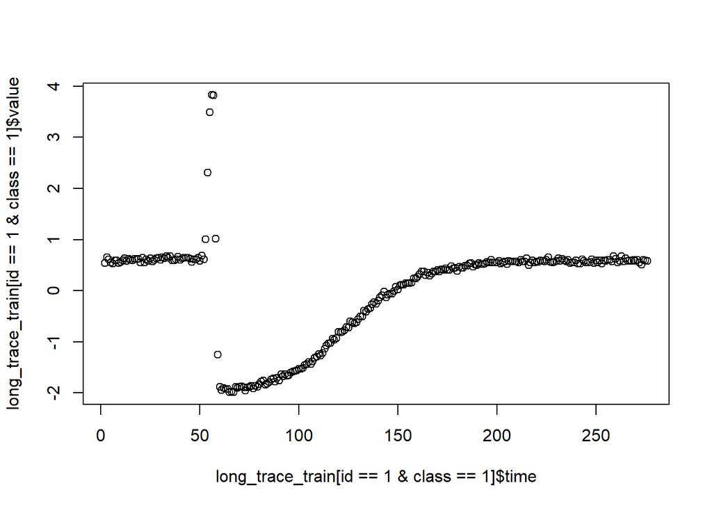

```r
plot(x=long_trace_train[id==1 & class==1]$time,y=long_trace_train[id==1 &  class==1]$value)
```

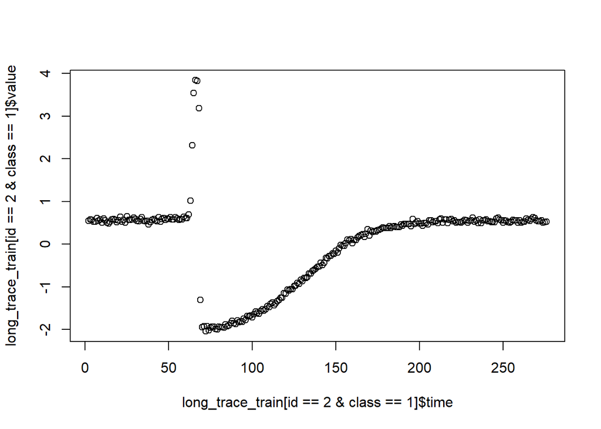

```r
plot(x=long_trace_train[id==2 & class==1]$time,y=long_trace_train[id==2 &  class==1]$value)
```

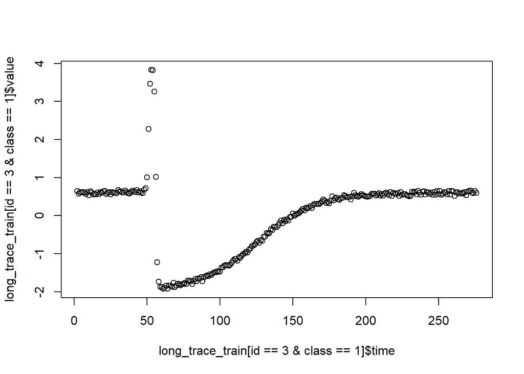

```r
plot(x=long_trace_train[id==3 & class==1]$time,y=long_trace_train[id==3 &  class==1]$value)
```

## Fused Lasso Approach

We will use fused lasso approach for one of our classification methods.

```r
train_row_2=nrow(trace_train)
test_row_2=nrow(trace_test)
f_res=vector("list",train_row_2)
for(i in 1:train_row_2){
      dt_2=long_trace_train[id==i]
      dt_2=as.matrix(dt_2[,4],rownames=FALSE)
      f_lasso=trendfilter(dt_2, ord=0)
      cv=cv.trendfilter(f_lasso)
      f_res[[i]]=predict.genlasso(f_lasso,cv$lambda.min)
}
```

[output not shown]

[output cut: 45 more lines]

[output not shown]

```r
fused_lasso_dt=vector('list',train_row_2)
for(i in seq(1:train_row_2)){
      fused_lasso_dt[[i]]=as.data.table(t(f_res[[i]]$fit))
}
lasso_fit=rbindlist(fused_lasso_dt)
head(lasso_fit,20)
```

```
##            V1        V2        V3        V4        V5        V6        V7
##  1: 0.5452519 0.6555001 0.6112391 0.5454131 0.5345190 0.5929649 0.5929649
##  2: 0.5415983 0.5714554 0.5621467 0.5214034 0.5274937 0.6035906 0.5409735
##  3: 0.6237060 0.6076419 0.6076419 0.6076419 0.6076419 0.6076419 0.5923020
##  4: 0.6223170 0.6223170 0.6639603 0.6660432 0.6660432 0.6533468 0.6212771
##  5: 0.5936805 0.5983572 0.5983572 0.5710080 0.5710080 0.5710080 0.5710080
##  6: 0.6186370 0.6186370 0.6186370 0.6309001 0.6158476 0.6144800 0.6714356
##  7: 0.6325821 0.6325821 0.6287770 0.6099543 0.6099543 0.6056934 0.6107200
##  8: 0.5433290 0.6080188 0.5691767 0.5741904 0.5373288 0.6051309 0.6185462
##  9: 0.5759193 0.5759193 0.6097102 0.6097102 0.5867305 0.5901081 0.6088463
## 10: 0.6171955 0.6171955 0.6005753 0.6005753 0.6070859 0.6070859 0.6070859
## 11: 0.5398700 0.5828315 0.6215369 0.6134161 0.5416378 0.5416378 0.5423302
## 12: 0.6221252 0.6221252 0.6693219 0.5717608 0.5783299 0.5783299 0.5990306
## 13: 0.5130968 0.5908240 0.5908240 0.5658481 0.6243473 0.6071099 0.6052423
## 14: 0.5695660 0.5653637 0.5653637 0.5502756 0.5575727 0.5575727 0.5447605
```

[output cut: 909 more lines]

## Piecewise Approximation Approach

We will use piecewise approximation approach for one of our classification methods.

```r
train_row_2=nrow(trace_train)
test_row_2=nrow(trace_test)
seg_len_1=5
long_trace_train=long_trace_train[order(id,time)]
paa_res=vector('list',train_row_2)
for (i in 1:train_row_2){
      data_ts=long_trace_train[id==i]$value
      paa_rep=repr_paa(data_ts,seg_len_1,meanC)
      paa_res[[i]]=paa_rep
}
paa_list=vector('list', train_row_2)
for (i in 1:train_row_2) {
      paa_list[[i]]=as.data.table(t(paa_res[[i]]))
}
paa_seg_5=rbindlist(paa_list)
head(paa_seg_5,20)
```

```
##            V1        V2        V3        V4        V5        V6        V7
##  1: 0.5781483 0.5771910 0.6074151 0.6101428 0.5895897 0.6291376 0.6420346
##  2: 0.5447743 0.5646683 0.5306090 0.5706730 0.5608947 0.5787209 0.5647890
##  3: 0.6142914 0.5942764 0.5773962 0.6150510 0.5924052 0.6154674 0.6268629
##  4: 0.6494254 0.6306168 0.6111617 0.6300365 0.6104362 0.6361464 0.6316360
##  5: 0.5847822 0.5758944 0.5475803 0.5641877 0.5728544 0.5747782 0.5931642
##  6: 0.6234890 0.6309031 0.6240886 0.6186309 0.6351903 0.6192768 0.5838556
##  7: 0.6253264 0.6066439 0.6254636 0.6436456 0.6183480 0.5886866 0.6187619
##  8: 0.5664048 0.5861587 0.6102511 0.6167857 0.5872426 0.5897709 0.5945187
##  9: 0.5898186 0.6216568 0.6343278 0.6390229 0.6226594 0.6401753 0.6358862
## 10: 0.6078695 0.6221965 0.6105099 0.6073060 0.6238602 0.6340767 0.6108975
## 11: 0.5786702 0.5586734 0.5967038 0.5739601 0.5656526 0.5964182 0.6056128
## 12: 0.6105379 0.5944506 0.5911093 0.6121128 0.6417908 0.5901591 0.6161631
## 13: 0.5790969 0.5852938 0.5589012 0.5996187 0.5926977 0.5577376 0.5956017
## 14: 0.5603642 0.5806323 0.5724893 0.5760281 0.5544928 0.5737713 0.5878905
```

[output cut: 174 more lines]

```r
seg_len_2=10
long_plane_train=long_trace_train[order(id,time)]
paa_res=vector('list',train_row_2)
for (i in 1:train_row_2){
      data_ts=long_trace_train[id==i]$value
      paa_rep=repr_paa(data_ts,seg_len_2,meanC)
      paa_res[[i]]=paa_rep
}
paa_list=vector('list', train_row_2)
for (i in 1:train_row_2) {
      paa_list[[i]]=as.data.table(t(paa_res[[i]]))
}
paa_seg_10=rbindlist(paa_list)
head(paa_seg_10,20)
```

```
##            V1        V2        V3        V4        V5          V6         V7
##  1: 0.5776697 0.6087789 0.6093636 0.6320169 0.6246475  1.09979035 -1.9219559
##  2: 0.5547213 0.5506410 0.5698078 0.5504771 0.5817320  0.59664947  1.3226489
##  3: 0.6042839 0.5962236 0.6039363 0.6193802 0.8421644  0.67730734 -1.8491343
##  4: 0.6400211 0.6205991 0.6232913 0.6283944 0.6120808  0.60449500  0.6211115
##  5: 0.5803383 0.5558840 0.5738163 0.5966090 0.5737320  0.59005032  0.5765158
##  6: 0.6271961 0.6213598 0.6272336 0.6034522 0.5916658  0.62570391  0.6426297
##  7: 0.6159852 0.6345546 0.6035173 0.6168247 0.6116653  0.62824106  0.6152646
##  8: 0.5762818 0.6135184 0.5885067 0.6133262 0.6460734  0.86580381 -1.9625196
##  9: 0.6057377 0.6366753 0.6314174 0.6225151 0.6116377  0.60145356  0.6103583
## 10: 0.6150330 0.6089080 0.6289685 0.6235787 0.6399560  0.68046563  0.4896491
## 11: 0.5686718 0.5853320 0.5810354 0.6070538 1.1019717  0.07325428 -1.9273882
## 12: 0.6024943 0.6016111 0.6159750 0.6394142 0.6967460  0.51740513 -1.9243273
## 13: 0.5821954 0.5792600 0.5752176 0.5846602 0.5738041  0.59932012  0.5969092
## 14: 0.5704983 0.5742587 0.5641321 0.6029787 0.5804416  0.66798267  1.0512921
```

[output cut: 90 more lines]

```r
seg_len_3=20
long_plane_train=long_trace_train[order(id,time)]
paa_res=vector('list',train_row_2)
for (i in 1:train_row_2){
      data_ts=long_trace_train[id==i]$value
      paa_rep=repr_paa(data_ts,seg_len_3,meanC)
      paa_res[[i]]=paa_rep
}
paa_list=vector('list', train_row_2)
for (i in 1:train_row_2) {
      paa_list[[i]]=as.data.table(t(paa_res[[i]]))
}
paa_seg_20=rbindlist(paa_list)
head(paa_seg_20,20)
```

```
##            V1        V2        V3         V4          V5         V6         V7
##  1: 0.5932243 0.6206903 0.8622189 -1.8979415 -1.67763083 -1.1848292 -0.4820813
##  2: 0.5526811 0.5601425 0.5891908 -0.3236361 -1.81090835 -1.4026011 -0.7877773
##  3: 0.6002537 0.6116583 0.7597359 -1.8116158 -1.57692494 -1.1361356 -0.5137911
##  4: 0.6303101 0.6258429 0.6082879  0.6247389  0.64206740  1.4841699 -1.5552639
##  5: 0.5681112 0.5852127 0.5818912  0.5828664  1.00803609 -1.1818519 -1.7313825
##  6: 0.6242779 0.6153429 0.6086849  0.6388206  0.75842953 -1.7957340 -1.5807996
##  7: 0.6252699 0.6101710 0.6199532  0.6272819  1.25709016 -1.8137184 -1.6227791
##  8: 0.5949001 0.6009165 0.7559386 -1.9245839 -1.63200999 -1.1039108 -0.4308280
##  9: 0.6212065 0.6269662 0.6065456  0.6273210  0.63514214  0.5277643 -1.7714924
## 10: 0.6119705 0.6262736 0.6602108 -0.7304558 -1.79810640 -1.3750211 -0.7724701
## 11: 0.5770019 0.5940446 0.5876130 -1.8824700 -1.58316578 -1.0102480 -0.3586541
## 12: 0.6020527 0.6276946 0.6070755 -1.8788193 -1.63133198 -1.1218460 -0.4560895
## 13: 0.5807277 0.5799389 0.5865621  0.6008184  0.02046882 -1.8355960 -1.5016595
## 14: 0.5723785 0.5835554 0.6242121 -0.4276881 -1.76883232 -1.4117509 -0.8073633
```

[output cut: 48 more lines]

[figure not shown]

```r
plot(x=long_plane_train[id==1 & class==1]$time,y=long_plane_train[id==1 & class==1]$paa_seg_5)
```

[figure not shown]

```r
plot(x=long_plane_train[id==2 & class==1]$time,y=long_plane_train[id==2 & class==1]$paa_seg_10)
```

[figure not shown]

```r
plot(x=long_plane_train[id==3 & class==1]$time,y=long_plane_train[id==3 & class==1]$paa_seg_20)
```

```r
trace_train_raw=data.frame()
for(i in 1:length(unique(long_trace_train$id))){
    trace_train_raw=rbind(trace_train_raw,t(as.data.frame(long_trace_train[id==i]$value)))
}
row.names(trace_train_raw)=NULL
```

## Raw time series distances

```r
dataset='Trace'
main_path=sprintf('D:/Boğaziçi/İe48b/Univariate_arff/Trace/ClassificationData')
dist_path=sprintf('D:/Boğaziçi/İe48b/Univariate_arff/Trace/ClassificationData/distances')
large_number=10000

dist_euc_1=as.matrix(dist(trace_train_raw))
diag(dist_euc_1)=large_number
fwrite(dist_euc_1,sprintf('%s/_euc_dist_1.csv',dist_path),col.names=F)
```

```
## x being coerced from class: matrix to data.table
```

```r
dist_dtw_1=as.matrix(dtwDist(trace_train_raw))
diag(dist_dtw_1)=large_number
fwrite(dist_dtw_1,sprintf('%s/_dtw_raw_dist_1.csv',dist_path),col.names=F)
```

```
## x being coerced from class: matrix to data.table
```

```r
dist_lcss_1=TSDatabaseDistances(trace_train_raw,distance='lcss',epsilon=0.05)
dist_lcss_1=as.matrix(dist_lcss_1)
diag(dist_lcss_1)=large_number
fwrite(dist_lcss_1,sprintf('%s/_lcss_dist_1.csv',dist_path),col.names=F)
```

```
## x being coerced from class: matrix to data.table
```

```r
dist_erp_1=TSDatabaseDistances(trace_train_raw,distance='erp',g=0.5)
dist_erp_1=as.matrix(dist_erp_1)
diag(dist_erp_1)=large_number
fwrite(dist_erp_1,sprintf('%s/_erp_dist_1.csv', dist_path),col.names=F)
```

```
## x being coerced from class: matrix to data.table
```

## Fused Lasso Distances

```r
dist_euc_lasso=as.matrix(dist(lasso_fit))
diag(dist_euc_lasso)=large_number
fwrite(dist_euc_lasso,sprintf('%s_euc_lasso_dist.csv',dist_path),col.names=F)
```

```
## x being coerced from class: matrix to data.table
```

```r
dist_dtw_2=as.matrix(dtwDist(lasso_fit))
diag(dist_dtw_2)=large_number
fwrite(dist_dtw_2,sprintf('%s/_dtw_raw_dist_2.csv',dist_path),col.names=F)
```

```
## x being coerced from class: matrix to data.table
```

```r
dist_lcss_2=TSDatabaseDistances(lasso_fit,distance='lcss',epsilon=0.07)
dist_lcss_2=as.matrix(dist_lcss_2)
diag(dist_lcss_2)=large_number
fwrite(dist_lcss_2,sprintf('%s/_lcss_dist_2.csv',dist_path),col.names=F)
```

```
## x being coerced from class: matrix to data.table
```

```r
dist_erp_2=TSDatabaseDistances(lasso_fit,distance='erp',g=0.7)
dist_erp_2=as.matrix(dist_erp_2)
diag(dist_erp_2)=large_number
fwrite(dist_erp_2,sprintf('%s/_erp_dist_2.csv', dist_path),col.names=F)
```

```
## x being coerced from class: matrix to data.table
```

## Piecewise Approximation Approach distances

```r
dist_euc_paa=as.matrix(dist(paa_seg_5))
diag(dist_euc_paa)=large_number
fwrite(dist_euc_paa,sprintf('%s/_euc_raw_paa_segment_5_dist.csv',dist_path),col.names=F)
```

```
## x being coerced from class: matrix to data.table
```

```r
dist_euc_3=as.matrix(dist(paa_seg_5))
diag(dist_euc_3)=large_number
fwrite(dist_euc_3,sprintf('%s/_euc_dist_3.csv',dist_path),col.names=F)
```

```
## x being coerced from class: matrix to data.table
```

```r
dist_dtw_3=as.matrix(dtwDist(paa_seg_5))
diag(dist_dtw_3)=large_number
fwrite(dist_dtw_3,sprintf('%s/_dtw_raw_dist_3.csv',dist_path),col.names=F)
```

```
## x being coerced from class: matrix to data.table
```

```r
dist_lcss_3=TSDatabaseDistances(paa_seg_5,distance='lcss',epsilon=0.09)
dist_lcss_3=as.matrix(dist_lcss_3)
diag(dist_lcss_3)=large_number
fwrite(dist_lcss_3,sprintf('%s/_lcss_dist_3.csv',dist_path),col.names=F)
```

```
## x being coerced from class: matrix to data.table
```

```r
dist_erp_3=TSDatabaseDistances(paa_seg_5,distance='erp',g=0.9)
dist_erp_3=as.matrix(dist_erp_3)
diag(dist_erp_3)=large_number
fwrite(dist_erp_3,sprintf('%s/_erp_dist_3.csv', dist_path),col.names=F)
```

```
## x being coerced from class: matrix to data.table
```

```r
set.seed(213)
nof_rep=10
n_fold=10
trainclass=c()
for(i in 1:length(unique(long_trace_train$id))){
    trainclass=c(trainclass,unique(long_trace_train[id==i,class]))
}
cv_indices=generateCVRuns(trainclass,ntimes=nof_rep,nfold=n_fold,leaveOneOut=FALSE,stratified=TRUE)
str(cv_indices)
```

```
## List of 10
##  $ Run  1 :List of 10
##   ..$ Fold  1 : int [1:10] 24 23 8 28 45 54 49 82 90 96
##   ..$ Fold  2 : int [1:10] 12 13 14 38 35 61 68 80 95 85
##   ..$ Fold  3 : int [1:10] 16 5 4 47 36 53 63 88 84 75
##   ..$ Fold  4 : int [1:10] 9 15 19 43 42 64 52 77 87 93
##   ..$ Fold  5 : int [1:10] 1 25 22 37 33 56 58 100 71 83
##   ..$ Fold  6 : int [1:10] 2 21 10 46 41 57 62 73 91 99
##   ..$ Fold  7 : int [1:10] 26 7 29 30 27 66 59 89 98 86
##   ..$ Fold  8 : int [1:10] 3 18 32 39 55 69 60 92 94 70
##   ..$ Fold  9 : int [1:10] 20 6 40 31 50 67 48 76 74 79
##   ..$ Fold  10: int [1:10] 11 17 34 44 51 65 78 97 72 81
##  $ Run  2 :List of 10
##   ..$ Fold  1 : int [1:10] 24 13 12 30 43 62 58 73 76 100
##   ..$ Fold  2 : int [1:10] 11 2 22 40 42 66 56 70 85 79
##   ..$ Fold  3 : int [1:10] 8 18 6 33 34 53 55 99 71 92
##   ..$ Fold  4 : int [1:10] 16 5 7 45 32 50 52 90 81 82
##   ..$ Fold  5 : int [1:10] 20 9 10 35 44 54 49 72 88 83
##   ..$ Fold  6 : int [1:10] 1 25 21 29 27 67 57 93 97 78
##   ..$ Fold  7 : int [1:10] 19 3 38 28 36 51 48 74 91 94
##   ..$ Fold  8 : int [1:10] 15 17 46 37 65 60 61 96 95 89
##   ..$ Fold  9 : int [1:10] 23 26 31 41 68 63 59 75 84 98
##   ..$ Fold  10: int [1:10] 4 14 47 39 69 64 86 80 77 87
##  $ Run  3 :List of 10
##   ..$ Fold  1 : int [1:10] 22 19 21 29 36 50 59 71 88 85
##   ..$ Fold  2 : int [1:10] 2 7 14 31 46 63 56 100 92 79
##   ..$ Fold  3 : int [1:10] 5 15 9 28 37 55 61 75 74 91
##   ..$ Fold  4 : int [1:10] 10 13 26 43 38 64 60 89 70 77
##   ..$ Fold  5 : int [1:10] 3 6 16 39 35 53 65 95 96 99
##   ..$ Fold  6 : int [1:10] 20 4 12 30 27 52 62 98 94 83
##   ..$ Fold  7 : int [1:10] 1 18 34 45 44 49 66 93 82 84
##   ..$ Fold  8 : int [1:10] 8 23 42 33 48 51 69 90 76 86
##   ..$ Fold  9 : int [1:10] 24 17 40 47 57 67 68 73 72 78
##   ..$ Fold  10: int [1:10] 25 11 41 32 54 58 81 80 97 87
##  $ Run  4 :List of 10
##   ..$ Fold  1 : int [1:10] 10 4 23 32 46 62 61 74 92 85
##   ..$ Fold  2 : int [1:10] 2 14 5 45 29 63 60 81 70 96
##   ..$ Fold  3 : int [1:10] 16 6 24 41 43 69 50 72 90 76
##   ..$ Fold  4 : int [1:10] 22 20 9 44 31 57 54 75 100 98
##   ..$ Fold  5 : int [1:10] 19 3 11 34 37 48 68 91 88 99
```

[output cut: 56 more lines]

```
##   ..$ Fold  7 : int [1:10] 12 10 40 35 29 59 55 99 87 79
##   ..$ Fold  8 : int [1:10] 20 4 44 34 60 62 49 100 92 78
##   ..$ Fold  9 : int [1:10] 14 1 39 37 66 63 69 93 95 71
##   ..$ Fold  10: int [1:10] 5 16 31 42 61 67 81 88 96 76
##  $ Run  10:List of 10
##   ..$ Fold  1 : int [1:10] 24 13 22 35 36 49 51 95 74 73
##   ..$ Fold  2 : int [1:10] 8 2 19 42 28 55 65 84 91 96
##   ..$ Fold  3 : int [1:10] 4 1 14 39 46 66 53 76 85 72
##   ..$ Fold  4 : int [1:10] 17 5 21 27 40 50 59 99 90 97
##   ..$ Fold  5 : int [1:10] 18 9 12 41 45 68 57 89 100 92
##   ..$ Fold  6 : int [1:10] 25 7 23 32 38 52 69 87 88 98
##   ..$ Fold  7 : int [1:10] 6 20 47 44 33 60 63 86 77 71
##   ..$ Fold  8 : int [1:10] 15 10 31 43 64 56 58 79 80 78
##   ..$ Fold  9 : int [1:10] 26 3 34 30 61 62 67 83 93 75
##   ..$ Fold  10: int [1:10] 16 11 29 37 54 48 82 81 70 94
```

```r
dist_folder=sprintf('D:/Boğaziçi/İe48b/Univariate_arff/Trace/ClassificationData/distances')
dist_files=list.files(dist_folder, full.names=T)
```

```r
k_levels=c(1,3,5)
approach_file=list.files(dist_folder)
result=vector('list',length(dist_files)*nof_rep*n_fold*length(k_levels))
iter=1
for(m in 1:length(dist_files)){ #
    dist_mat=as.matrix(fread(dist_files[m],header=FALSE))
    for(i in 1:nof_rep){
        this_fold=cv_indices[[i]]
        for(j in 1:n_fold){
            test_indices=this_fold[[j]]
            for(k in 1:length(k_levels)){
                current_k=k_levels[k]
                current_fold=nn_classify_cv(dist_mat,trainclass,test_indices,k=current_k)
                accuracy=sum(trainclass[test_indices]==current_fold$prediction$predicted)/length(test_indices)
                tmp=data.table(approach=approach_file[m],repid=i,foldid=j,
                               k=current_k,acc=accuracy)
                result[[iter]]=tmp
                iter=iter+1

            }

        }

    }

}
```

```r
final_results=rbindlist(result)
summarized_results=final_results[,list(avg_acc=mean(acc),sdev_acc=sd(acc),result_count=.N),by=list(approach,k)]
summarized_results[order(-avg_acc)]
```

```
##                            approach k avg_acc   sdev_acc result_count
##  1:             _dtw_raw_dist_1.csv 5   0.949 0.06889459          100
##  2:             _dtw_raw_dist_2.csv 3   0.901 0.08102251          100
##  3:             _dtw_raw_dist_1.csv 3   0.879 0.08562899          100
##  4:                 _erp_dist_2.csv 3   0.867 0.08534541          100
##  5:             _dtw_raw_dist_2.csv 5   0.852 0.09372213          100
##  6:             _dtw_raw_dist_3.csv 5   0.850 0.09692234          100
##  7:             _dtw_raw_dist_2.csv 1   0.836 0.10398135          100
##  8:                 _erp_dist_1.csv 3   0.834 0.10368951          100
##  9:                 _erp_dist_1.csv 1   0.829 0.10376255          100
## 10:             _dtw_raw_dist_1.csv 1   0.816 0.09180568          100
## 11:             _dtw_raw_dist_3.csv 3   0.810 0.09481508          100
## 12:                 _erp_dist_1.csv 5   0.810 0.08932971          100
## 13:                 _erp_dist_2.csv 1   0.809 0.10159834          100
## 14:                 _erp_dist_3.csv 3   0.805 0.11135075          100
```

[output cut: 23 more lines]

```r
overall_results_summary=final_results[,list(avg_acc=mean(acc),sdev_acc=sd(acc),result_count=.N),by=list(approach,k)]
overall_results_summary[which.max(overall_results_summary$avg_acc),]
```

```
##               approach k avg_acc   sdev_acc result_count
## 1: _dtw_raw_dist_1.csv 5   0.949 0.06889459          100
```

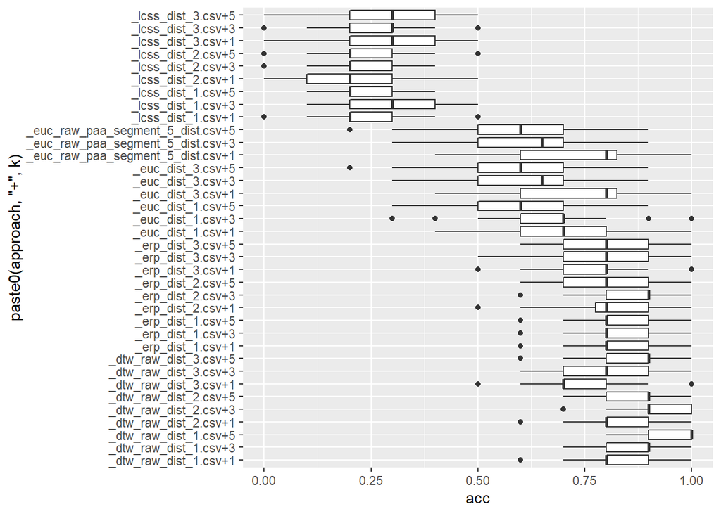

```r
ggplot(final_results,aes(x=paste0(approach,'+',k),y=acc))+geom_boxplot()+coord_flip()
```

Best result is from k=5, dtw distance 1 value which is 0.949. It is from raw dataset.

## 3rd Dataset Ham

## Data Manipulation

We read our data with fread function. We do some data manipulation to understand the data easier.

```r
ham_train=fread("D:/Boğaziçi/İe48b/Univariate_arff/Ham/Ham_TRAIN.txt")
ham_test=fread("D:/Boğaziçi/İe48b/Univariate_arff/Ham/Ham_TEST.txt")
head(ham_train,10)
```

```
##     V1         V2         V3          V4          V5          V6          V7
##  1:  1  0.1140252  0.1048898  0.09575441  0.08661899  0.08661899  0.08661899
##  2:  1 -0.8361366 -0.8229271 -0.81652248 -0.81932450 -0.83133312 -0.84974635
##  3:  1 -0.6957107 -0.7020155 -0.69531667 -0.67719050 -0.64054412 -0.55897637
##  4:  1 -0.7988984 -0.7883313 -0.78020270 -0.77938985 -0.78060913 -0.78142198
##  5:  1 -0.5234923 -0.4309753 -0.37810842 -0.35828335 -0.36489171 -0.40454185
##  6:  1 -0.7138282 -0.7507403 -0.77940612 -0.77979880 -0.77233784 -0.75780859
##  7:  1 -0.5404861 -0.5241815 -0.52418155 -0.53640994 -0.56290477 -0.58858438
##  8:  1 -0.5026098 -0.5202618 -0.54968193 -0.58498603 -0.62617415 -0.65559424
##  9:  1 -0.8393183 -0.8275431 -0.80713282 -0.77887238 -0.74590186 -0.71175383
## 10:  1 -0.7776114 -0.7741726 -0.77038985 -0.76591939 -0.75904175 -0.74975693
##              V8          V9         V10         V11         V12         V13
##  1:  0.07748358  0.07748358  0.07748358  0.07748358  0.07748358  0.07748358
##  2: -0.86015383 -0.86135469 -0.85895296 -0.85495009 -0.85454980 -0.85695153
##  3: -0.43603368 -0.36510520 -0.36116473 -0.39268850 -0.46755745 -0.52272404
```

[output cut: 766 more lines]

```r
head(ham_test,10)
```

```
##     V1         V2         V3         V4         V5         V6         V7
##  1:  1 -0.7285873 -0.6145647 -0.5157452 -0.4397302 -0.4093242 -0.4093242
##  2:  1 -0.8751164 -0.8672832 -0.8701691 -0.8747041 -0.8821250 -0.8903705
##  3:  1 -0.3973633 -0.3882884 -0.3746761 -0.3429140 -0.3383765 -0.3383765
##  4:  1 -0.6694625 -0.6765209 -0.6783784 -0.6780069 -0.6761494 -0.6702055
##  5:  1 -0.6356947 -0.6154780 -0.6132317 -0.6163765 -0.6271587 -0.6469262
##  6:  1 -0.8588671 -0.8578772 -0.8192696 -0.7559136 -0.7267105 -0.7153262
##  7:  1 -1.2870160 -1.2799259 -1.2751991 -1.2657456 -1.2639730 -1.2846526
##  8:  1 -0.6940312 -0.6905146 -0.6813714 -0.6697666 -0.6690633 -0.6729316
##  9:  1 -0.6759255 -0.6751295 -0.6755275 -0.6763235 -0.6795075 -0.6854776
## 10:  1 -0.7921089 -0.8064168 -0.8216477 -0.8447249 -0.8668789 -0.8705713
##             V8         V9        V10        V11        V12        V13
##  1: -0.4245272 -0.4625347 -0.5081437 -0.5537527 -0.5993617 -0.6373693
##  2: -0.8903705 -0.8870723 -0.8858355 -0.8887214 -0.8957301 -0.9043878
##  3: -0.2930021 -0.2521651 -0.2521651 -0.2884646 -0.3293016 -0.3519889
```

[output cut: 766 more lines]

```r
setnames(ham_train,"V1","class")
ham_train=ham_train[order(class)]
ham_train[,class:=as.character(class)]
ham_train[,id:=1:.N]
long_ham_train=melt(ham_train,id.vars=c('id','class'))
long_ham_train[,time:=as.numeric(gsub("\\D", "", variable))]
long_ham_train=long_ham_train[,list(id,class,time,value)]
long_ham_train=long_ham_train[order(id,time)]
head(long_ham_train,20)
```

```
##     id class time      value
##  1:  1     1    2 0.11402523
##  2:  1     1    3 0.10488982
##  3:  1     1    4 0.09575441
##  4:  1     1    5 0.08661899
##  5:  1     1    6 0.08661899
##  6:  1     1    7 0.08661899
##  7:  1     1    8 0.07748358
##  8:  1     1    9 0.07748358
##  9:  1     1   10 0.07748358
## 10:  1     1   11 0.07748358
## 11:  1     1   12 0.07748358
## 12:  1     1   13 0.07748358
## 13:  1     1   14 0.07748358
## 14:  1     1   15 0.07748358
## 15:  1     1   16 0.07748358
## 16:  1     1   17 0.07748358
## 17:  1     1   18 0.07748358
## 18:  1     1   19 0.06834816
## 19:  1     1   20 0.06834816
## 20:  1     1   21 0.06834816
```

## Visualization

We use some plots to see our data and have some idea about the patterns.

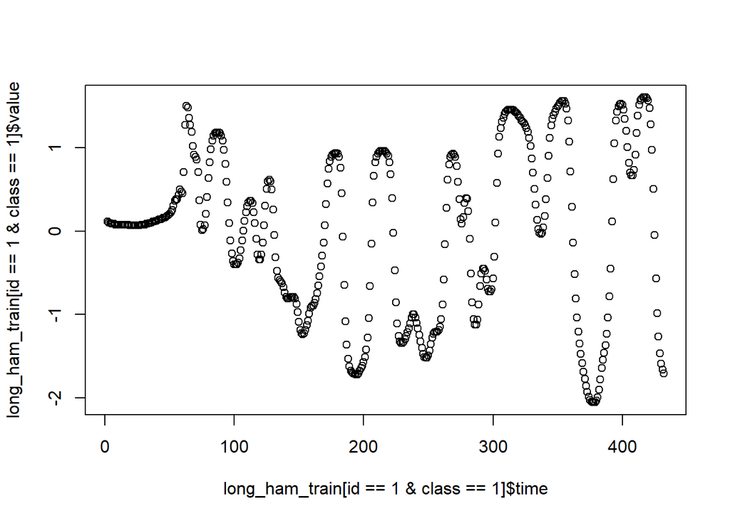

```r
plot(x=long_ham_train[id==1 & class==1]$time,y=long_ham_train[id==1 &  class==1]$value)
```

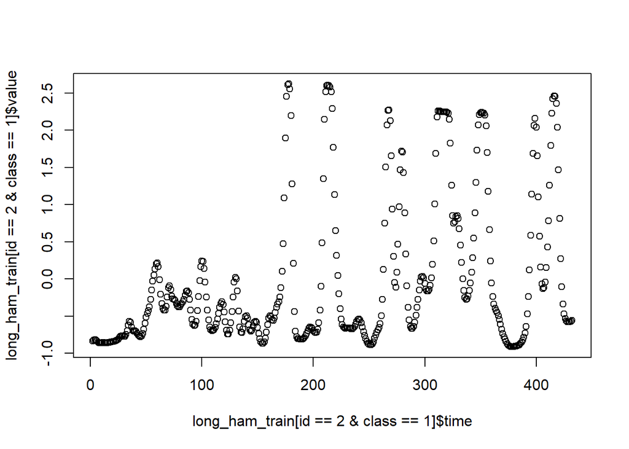

```r
plot(x=long_ham_train[id==2 & class==1]$time,y=long_ham_train[id==2 &  class==1]$value)
```

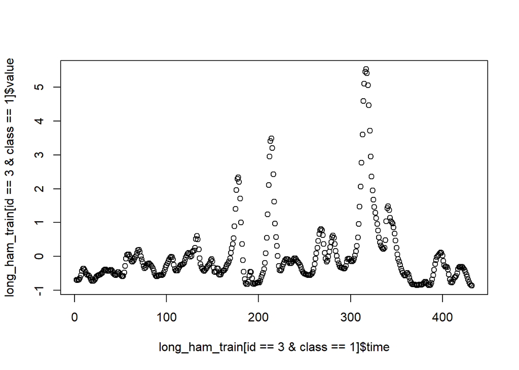

```r
plot(x=long_ham_train[id==3 & class==1]$time,y=long_ham_train[id==3 &  class==1]$value)
```

## Fused Lasso Approach

We will use fused lasso approach for one of our classification methods.

```r
train_row_3=nrow(ham_train)
test_row_3=nrow(ham_test)
f_res=vector("list",train_row_3)
for(i in 1:train_row_3){
      dt_3=long_ham_train[id==i]
      dt_3=as.matrix(dt_3[,4],rownames=FALSE)
      f_lasso=trendfilter(dt_3, ord=0)
      cv=cv.trendfilter(f_lasso)
      f_res[[i]]=predict.genlasso(f_lasso,cv$lambda.min)
}
```

[output not shown]

[output cut: 54 more lines]

[output not shown]

```r
fused_lasso_dt=vector('list',train_row_3)
for(i in seq(1:train_row_3)){
      fused_lasso_dt[[i]]=as.data.table(t(f_res[[i]]$fit))
}
lasso_fit=rbindlist(fused_lasso_dt)
head(lasso_fit,20)
```

```
##             V1         V2          V3          V4          V5          V6
##  1:  0.1140252  0.1048898  0.09575441  0.08661899  0.08661899  0.08661899
##  2: -0.8361366 -0.8229271 -0.81652248 -0.81932450 -0.83133312 -0.84974635
##  3: -0.6957107 -0.7020155 -0.69531667 -0.67719050 -0.64054412 -0.55897637
##  4: -0.7986951 -0.7883313 -0.78020270 -0.77979628 -0.78060913 -0.78101555
##  5: -0.5234923 -0.4309753 -0.37810842 -0.35828335 -0.36489171 -0.40454185
##  6: -0.7138282 -0.7507403 -0.77940612 -0.77979880 -0.77233784 -0.75780859
##  7: -0.5404861 -0.5241815 -0.52418155 -0.53640994 -0.56290477 -0.58858438
##  8: -0.5026098 -0.5202618 -0.54968193 -0.58498603 -0.62617415 -0.65559424
##  9: -0.8393183 -0.8275431 -0.80713282 -0.77887238 -0.74590186 -0.71175383
## 10: -0.7776114 -0.7741726 -0.77038985 -0.76591939 -0.75904175 -0.74975693
## 11: -0.6641856 -0.6393778 -0.60111486 -0.54351021 -0.47623470 -0.43418750
## 12: -0.9037662 -0.9342773 -0.94702826 -0.95613606 -0.96569925 -0.97571783
## 13: -1.0216963 -0.9711595 -0.94456124 -0.94828500 -0.95786038 -0.95413662
## 14: -0.8903745 -0.8803403 -0.88644809 -0.90695285 -0.93182033 -0.93836440
```

[output cut: 1476 more lines]

## Piecewise Approximation Approach

We will use piecewise approximation approach for one of our classification methods.

```r
train_row_3=nrow(ham_train)
test_row_3=nrow(ham_test)
seg_len_1=5
long_ham_train=long_ham_train[order(id,time)]
paa_res=vector('list',train_row_3)
for (i in 1:train_row_3){
      data_ts=long_ham_train[id==i]$value
      paa_rep=repr_paa(data_ts,seg_len_1,meanC)
      paa_res[[i]]=paa_rep
}
paa_list=vector('list', train_row_3)
for (i in 1:train_row_3) {
      paa_list[[i]]=as.data.table(t(paa_res[[i]]))
}
paa_seg_5=rbindlist(paa_list)
head(paa_seg_5,20)
```

```
##              V1          V2          V3          V4          V5          V6
##  1:  0.09758149  0.07931066  0.07748358  0.07200233  0.06834816  0.07565649
##  2: -0.82524875 -0.85703158 -0.85719170 -0.84534318 -0.81652248 -0.76840792
##  3: -0.68215549 -0.42279370 -0.53399379 -0.69862666 -0.60705012 -0.50483430
##  4: -0.78548626 -0.77150516 -0.75061480 -0.73996640 -0.66583406 -0.64640684
##  5: -0.41115021 -0.55389072 -0.64376438 -0.67019781 -0.65698110 -0.62790433
##  6: -0.75922225 -0.75757298 -0.74257252 -0.67950773 -0.65995215 -0.59947907
##  7: -0.53763277 -0.58662783 -0.51692604 -0.48586595 -0.54464371 -0.46303963
##  8: -0.55674275 -0.67913031 -0.65088703 -0.50025618 -0.35315574 -0.42023353
##  9: -0.79975370 -0.65884401 -0.62234094 -0.62171293 -0.58042129 -0.36360091
## 10: -0.76942699 -0.72183371 -0.70181978 -0.73008688 -0.70904131 -0.61894422
## 11: -0.58488464 -0.43166467 -0.52416850 -0.57395237 -0.45689299 -0.23992948
## 12: -0.94138143 -1.02362485 -0.99675684 -0.86232574 -0.88964913 -0.76988158
## 13: -0.96871249 -0.90913232 -0.82135799 -0.73677544 -0.71464567 -0.60889089
## 14: -0.89918722 -0.91663808 -0.88828043 -0.84116311 -0.82318872 -0.76106365
```

[output cut: 300 more lines]

```r
seg_len_2=10
long_ham_train=long_ham_train[order(id,time)]
paa_res=vector('list',train_row_3)
for (i in 1:train_row_3){
      data_ts=long_ham_train[id==i]$value
      paa_rep=repr_paa(data_ts,seg_len_2,meanC)
      paa_res[[i]]=paa_rep
}
paa_list=vector('list', train_row_3)
for (i in 1:train_row_3) {
      paa_list[[i]]=as.data.table(t(paa_res[[i]]))
}
paa_seg_10=rbindlist(paa_list)
head(paa_seg_10,20)
```

```
##              V1          V2          V3         V4         V5           V6
##  1:  0.08844607  0.07474295  0.07200233  0.1076304  0.1724919  0.423715788
##  2: -0.84114017 -0.85126744 -0.79246520 -0.6658943 -0.6773425 -0.048370707
##  3: -0.55247459 -0.61631023 -0.55594221 -0.4100266 -0.5198869 -0.190621149
##  4: -0.77849571 -0.74529060 -0.65612045 -0.6678256 -0.6515685  0.022084749
##  5: -0.48252047 -0.65698110 -0.64244271 -0.3999160 -0.5327440  0.418859449
##  6: -0.75839762 -0.71104012 -0.62971561 -0.5421867 -0.5350006 -0.054121832
##  7: -0.56213030 -0.50139600 -0.50384167 -0.3937455 -0.1434712  0.192401755
##  8: -0.61793653 -0.57557160 -0.38669464 -0.5567427 -0.1836960 -0.024239150
##  9: -0.72929886 -0.62202694 -0.47201110 -0.1410499 -0.2572318 -0.198748339
## 10: -0.74563035 -0.71595333 -0.66399276 -0.6178094 -0.5257178 -0.496625386
## 11: -0.50827466 -0.54906044 -0.34841123 -0.3639687 -0.3855809 -0.105378460
## 12: -0.98250314 -0.92954129 -0.82976536 -0.6058501 -0.3946403 -0.355021354
## 13: -0.93892241 -0.77906671 -0.66176828 -0.6337337 -0.6488415 -0.093416137
## 14: -0.90791265 -0.86472177 -0.79212619 -0.7207522 -0.7157787 -0.219388910
```

[output cut: 153 more lines]

```r
seg_len_3=20
long_ham_train=long_ham_train[order(id,time)]
paa_res=vector('list',train_row_3)
for (i in 1:train_row_3){
      data_ts=long_ham_train[id==i]$value
      paa_rep=repr_paa(data_ts,seg_len_3,meanC)
      paa_res[[i]]=paa_rep
}
paa_list=vector('list', train_row_3)
for (i in 1:train_row_3) {
      paa_list[[i]]=as.data.table(t(paa_res[[i]]))
}
paa_seg_20=rbindlist(paa_list)
head(paa_seg_20,20)
```

```
##              V1          V2          V3          V4           V5          V6
##  1:  0.08159451  0.08981639  0.29810384  0.75487457  0.630176153 -0.02117890
##  2: -0.84620380 -0.72917974 -0.36285661 -0.27913647 -0.266807615 -0.45668401
##  3: -0.58439241 -0.48298439 -0.35525403 -0.09932044 -0.437176416 -0.21162386
##  4: -0.76189315 -0.66197301 -0.31474186 -0.29817995 -0.152150626 -0.42029102
##  5: -0.56975078 -0.52117936 -0.05694227  0.01938426  0.121152959 -0.02158755
##  6: -0.73471887 -0.58595116 -0.29456123 -0.30995438 -0.283880270 -0.38209012
##  7: -0.53176315 -0.44879356  0.02446528 -0.02485587 -0.290700939 -0.56486131
##  8: -0.59675407 -0.47171869 -0.10396759 -0.11602983  0.116388873 -0.48566381
##  9: -0.67566290 -0.30653052 -0.22799005 -0.37262855 -0.232974872 -0.39537428
## 10: -0.73079184 -0.64090108 -0.51117159 -0.51222043 -0.342308333 -0.54021243
## 11: -0.52866755 -0.35618996 -0.24547970 -0.36670176  0.013404861 -0.42005965
## 12: -0.95602221 -0.71780774 -0.37483082 -0.42947761 -0.052870136 -0.45823548
## 13: -0.85899456 -0.64775098 -0.37112883 -0.30833028  0.156793924 -0.14592116
## 14: -0.88631721 -0.75643918 -0.46758379 -0.54201171 -0.257911688 -0.28661835
```

[output cut: 69 more lines]

[figure not shown]

```r
plot(x=long_plane_train[id==1 & class==1]$time,y=long_plane_train[id==1 & class==1]$paa_seg_5)
```

[figure not shown]

```r
plot(x=long_plane_train[id==2 & class==1]$time,y=long_plane_train[id==2 & class==1]$paa_seg_10)
```

[figure not shown]

```r
plot(x=long_plane_train[id==3 & class==1]$time,y=long_plane_train[id==3 & class==1]$paa_seg_20)
```

```r
ham_train_raw=data.frame()
for(i in 1:length(unique(long_ham_train$id))){
    ham_train_raw=rbind(ham_train_raw,t(as.data.frame(long_ham_train[id==i]$value)))
}
row.names(ham_train_raw)=NULL
```

## Raw time series distances

```r
dataset='Ham'
main_path=sprintf('D:/Boğaziçi/İe48b/Univariate_arff/Ham/ClassificationData')
dist_path=sprintf('D:/Boğaziçi/İe48b/Univariate_arff/Ham/ClassificationData/distances')
large_number=10000

dist_euc_1=as.matrix(dist(ham_train_raw))
diag(dist_euc_1)=large_number
fwrite(dist_euc_1,sprintf('%s/_euc_dist_1.csv',dist_path),col.names=F)
```

```
## x being coerced from class: matrix to data.table
```

```r
dist_dtw_1=as.matrix(dtwDist(ham_train_raw))
diag(dist_dtw_1)=large_number
fwrite(dist_dtw_1,sprintf('%s/_dtw_raw_dist_1.csv',dist_path),col.names=F)
```

```
## x being coerced from class: matrix to data.table
```

```r
dist_lcss_1=TSDatabaseDistances(ham_train_raw,distance='lcss',epsilon=0.05)
dist_lcss_1=as.matrix(dist_lcss_1)
diag(dist_lcss_1)=large_number
fwrite(dist_lcss_1,sprintf('%s/_lcss_dist_1.csv',dist_path),col.names=F)
```

```
## x being coerced from class: matrix to data.table
```

```r
dist_erp_1=TSDatabaseDistances(ham_train_raw,distance='erp',g=0.5)
dist_erp_1=as.matrix(dist_erp_1)
diag(dist_erp_1)=large_number
fwrite(dist_erp_1,sprintf('%s/_erp_dist_1.csv', dist_path),col.names=F)
```

```
## x being coerced from class: matrix to data.table
```

## Fused Lasso Distances

```r
dist_euc_lasso=as.matrix(dist(lasso_fit))
diag(dist_euc_lasso)=large_number
fwrite(dist_euc_lasso,sprintf('%s_euc_lasso_dist.csv',dist_path),col.names=F)
```

```
## x being coerced from class: matrix to data.table
```

```r
dist_dtw_2=as.matrix(dtwDist(lasso_fit))
diag(dist_dtw_2)=large_number
fwrite(dist_dtw_2,sprintf('%s/_dtw_raw_dist_2.csv',dist_path),col.names=F)
```

```
## x being coerced from class: matrix to data.table
```

```r
dist_lcss_2=TSDatabaseDistances(lasso_fit,distance='lcss',epsilon=0.07)
dist_lcss_2=as.matrix(dist_lcss_2)
diag(dist_lcss_2)=large_number
fwrite(dist_lcss_2,sprintf('%s/_lcss_dist_2.csv',dist_path),col.names=F)
```

```
## x being coerced from class: matrix to data.table
```

```r
dist_erp_2=TSDatabaseDistances(lasso_fit,distance='erp',g=0.7)
dist_erp_2=as.matrix(dist_erp_2)
diag(dist_erp_2)=large_number
fwrite(dist_erp_2,sprintf('%s/_erp_dist_2.csv', dist_path),col.names=F)
```

```
## x being coerced from class: matrix to data.table
```

## Piecewise Approximation Approach distances

```r
dist_euc_paa=as.matrix(dist(paa_seg_5))
diag(dist_euc_paa)=large_number
fwrite(dist_euc_paa,sprintf('%s/_euc_raw_paa_segment_5_dist.csv',dist_path),col.names=F)
```

```
## x being coerced from class: matrix to data.table
```

```r
dist_euc_3=as.matrix(dist(paa_seg_5))
diag(dist_euc_3)=large_number
fwrite(dist_euc_3,sprintf('%s/_euc_dist_3.csv',dist_path),col.names=F)
```

```
## x being coerced from class: matrix to data.table
```

```r
dist_dtw_3=as.matrix(dtwDist(paa_seg_5))
diag(dist_dtw_3)=large_number
fwrite(dist_dtw_3,sprintf('%s/_dtw_raw_dist_3.csv',dist_path),col.names=F)
```

```
## x being coerced from class: matrix to data.table
```

```r
dist_lcss_3=TSDatabaseDistances(paa_seg_5,distance='lcss',epsilon=0.09)
dist_lcss_3=as.matrix(dist_lcss_3)
diag(dist_lcss_3)=large_number
fwrite(dist_lcss_3,sprintf('%s/_lcss_dist_3.csv',dist_path),col.names=F)
```

```
## x being coerced from class: matrix to data.table
```

```r
dist_erp_3=TSDatabaseDistances(paa_seg_5,distance='erp',g=0.9)
dist_erp_3=as.matrix(dist_erp_3)
diag(dist_erp_3)=large_number
fwrite(dist_erp_3,sprintf('%s/_erp_dist_3.csv', dist_path),col.names=F)
```

```
## x being coerced from class: matrix to data.table
```

```r
set.seed(213)
nof_rep=10
n_fold=10
trainclass=c()
for(i in 1:length(unique(long_ham_train$id))){
    trainclass=c(trainclass,unique(long_ham_train[id==i,class]))
}
cv_indices=generateCVRuns(trainclass,ntimes=nof_rep,nfold=n_fold,leaveOneOut=FALSE,stratified=TRUE)
str(cv_indices)
```

```
## List of 10
##  $ Run  1 :List of 10
##   ..$ Fold  1 : int [1:11] 44 25 31 39 46 1 79 99 75 53 ...
##   ..$ Fold  2 : int [1:11] 16 13 20 49 27 17 74 93 101 57 ...
##   ..$ Fold  3 : int [1:11] 9 21 28 30 52 59 60 97 68 63 ...
##   ..$ Fold  4 : int [1:11] 33 18 38 5 47 108 81 76 95 64 ...
##   ..$ Fold  5 : int [1:11] 23 14 35 37 7 67 56 71 73 91 ...
##   ..$ Fold  6 : int [1:11] 29 10 8 48 50 98 66 94 55 89 ...
##   ..$ Fold  7 : int [1:11] 34 40 42 24 41 72 105 104 82 85 ...
##   ..$ Fold  8 : int [1:11] 51 32 2 4 22 78 87 107 58 109 ...
##   ..$ Fold  9 : int [1:11] 3 11 12 15 26 106 61 84 102 88 ...
##   ..$ Fold  10: int [1:10] 43 6 19 36 45 70 65 54 86 69
##  $ Run  2 :List of 10
##   ..$ Fold  1 : int [1:11] 32 5 40 20 45 10 82 101 58 75 ...
##   ..$ Fold  2 : int [1:11] 31 50 14 8 28 1 65 90 66 84 ...
##   ..$ Fold  3 : int [1:11] 44 41 7 21 11 83 93 108 105 99 ...
##   ..$ Fold  4 : int [1:11] 48 22 36 29 13 104 59 109 91 100 ...
##   ..$ Fold  5 : int [1:11] 35 15 9 49 46 87 88 98 76 53 ...
##   ..$ Fold  6 : int [1:11] 42 30 38 16 39 74 85 86 96 92 ...
##   ..$ Fold  7 : int [1:11] 51 47 19 17 6 55 56 78 77 54 ...
##   ..$ Fold  8 : int [1:11] 26 37 18 27 3 63 107 64 97 57 ...
##   ..$ Fold  9 : int [1:11] 4 12 33 24 34 81 89 68 103 62 ...
##   ..$ Fold  10: int [1:10] 52 25 23 2 43 70 73 95 60 79
##  $ Run  3 :List of 10
##   ..$ Fold  1 : int [1:11] 6 15 46 17 26 38 90 53 99 68 ...
##   ..$ Fold  2 : int [1:11] 20 47 42 1 44 11 105 97 62 92 ...
##   ..$ Fold  3 : int [1:11] 16 14 37 10 48 80 102 59 85 91 ...
##   ..$ Fold  4 : int [1:11] 5 19 41 43 32 64 77 71 72 76 ...
##   ..$ Fold  5 : int [1:11] 2 18 7 27 13 83 109 58 55 67 ...
##   ..$ Fold  6 : int [1:11] 40 3 24 50 35 81 56 87 73 69 ...
##   ..$ Fold  7 : int [1:11] 4 49 52 12 9 78 82 95 84 96 ...
##   ..$ Fold  8 : int [1:11] 25 34 8 23 22 108 63 86 94 75 ...
##   ..$ Fold  9 : int [1:11] 36 39 30 45 21 54 89 101 107 66 ...
##   ..$ Fold  10: int [1:10] 28 31 33 29 51 104 100 60 103 98
##  $ Run  4 :List of 10
##   ..$ Fold  1 : int [1:11] 5 6 14 40 39 12 85 75 54 57 ...
##   ..$ Fold  2 : int [1:11] 20 51 38 26 29 22 73 96 108 71 ...
##   ..$ Fold  3 : int [1:11] 19 43 2 17 50 69 105 107 106 97 ...
##   ..$ Fold  4 : int [1:11] 10 8 4 47 21 93 67 76 79 60 ...
##   ..$ Fold  5 : int [1:11] 27 34 11 18 37 98 109 62 100 68 ...
```

[output cut: 56 more lines]

```
##   ..$ Fold  7 : int [1:11] 43 21 7 38 33 66 64 55 89 96 ...
##   ..$ Fold  8 : int [1:11] 51 15 22 3 31 91 99 104 62 102 ...
##   ..$ Fold  9 : int [1:11] 50 45 47 39 30 54 107 109 92 87 ...
##   ..$ Fold  10: int [1:10] 40 48 23 28 26 60 105 90 95 53
##  $ Run  10:List of 10
##   ..$ Fold  1 : int [1:11] 21 27 41 4 43 52 90 101 102 89 ...
##   ..$ Fold  2 : int [1:11] 31 40 2 32 24 35 61 108 75 106 ...
##   ..$ Fold  3 : int [1:11] 12 47 10 19 17 54 72 63 76 91 ...
##   ..$ Fold  4 : int [1:11] 20 39 36 29 1 62 55 74 94 87 ...
##   ..$ Fold  5 : int [1:11] 8 22 49 46 50 96 59 79 77 53 ...
##   ..$ Fold  6 : int [1:11] 5 14 23 38 34 78 93 73 97 64 ...
##   ..$ Fold  7 : int [1:11] 28 15 44 30 51 100 69 56 81 99 ...
##   ..$ Fold  8 : int [1:11] 25 16 13 6 45 104 105 103 68 80 ...
##   ..$ Fold  9 : int [1:11] 3 7 18 42 26 70 98 82 92 57 ...
##   ..$ Fold  10: int [1:10] 33 11 9 37 48 86 71 95 58 65
```

```r
dist_folder=sprintf('D:/Boğaziçi/İe48b/Univariate_arff/Ham/ClassificationData/distances')
dist_files=list.files(dist_folder, full.names=T)
```

```r
k_levels=c(1,3,5)
approach_file=list.files(dist_folder)
result=vector('list',length(dist_files)*nof_rep*n_fold*length(k_levels))
iter=1
for(m in 1:length(dist_files)){ #
    dist_mat=as.matrix(fread(dist_files[m],header=FALSE))
    for(i in 1:nof_rep){
        this_fold=cv_indices[[i]]
        for(j in 1:n_fold){
            test_indices=this_fold[[j]]
            for(k in 1:length(k_levels)){
                current_k=k_levels[k]
                current_fold=nn_classify_cv(dist_mat,trainclass,test_indices,k=current_k)
                accuracy=sum(trainclass[test_indices]==current_fold$prediction$predicted)/length(test_indices)
                tmp=data.table(approach=approach_file[m],repid=i,foldid=j,
                               k=current_k,acc=accuracy)
                result[[iter]]=tmp
                iter=iter+1

            }

        }

    }

}
```

```r
final_results=rbindlist(result)
summarized_results=final_results[,list(avg_acc=mean(acc),sdev_acc=sd(acc),result_count=.N),by=list(approach,k)]
summarized_results[order(-avg_acc)]
```

```
##                            approach k   avg_acc   sdev_acc result_count
##  1:                 _euc_dist_3.csv 1 0.8342727 0.11454717          100
##  2: _euc_raw_paa_segment_5_dist.csv 1 0.8342727 0.11454717          100
##  3:                 _euc_dist_1.csv 1 0.8323636 0.11519008          100
##  4:                 _erp_dist_3.csv 3 0.8191818 0.11518700          100
##  5:                 _erp_dist_3.csv 1 0.8150909 0.11907356          100
##  6:                 _euc_dist_3.csv 3 0.8147273 0.11726906          100
##  7: _euc_raw_paa_segment_5_dist.csv 3 0.8147273 0.11726906          100
##  8:             _dtw_raw_dist_1.csv 3 0.8090000 0.11550255          100
##  9:             _dtw_raw_dist_2.csv 3 0.8090000 0.11550255          100
## 10:                 _euc_dist_1.csv 3 0.8036364 0.11005846          100
## 11:                 _erp_dist_3.csv 5 0.7996364 0.12411080          100
## 12:             _dtw_raw_dist_1.csv 1 0.7992727 0.11142049          100
## 13:             _dtw_raw_dist_2.csv 1 0.7992727 0.11142049          100
## 14:                 _erp_dist_1.csv 1 0.7977273 0.12262520          100
```

[output cut: 23 more lines]

```r
overall_results_summary=final_results[,list(avg_acc=mean(acc),sdev_acc=sd(acc),result_count=.N),by=list(approach,k)]
overall_results_summary[which.max(overall_results_summary$avg_acc),]
```

```
##           approach k   avg_acc  sdev_acc result_count
## 1: _euc_dist_3.csv 1 0.8342727 0.1145472          100
```

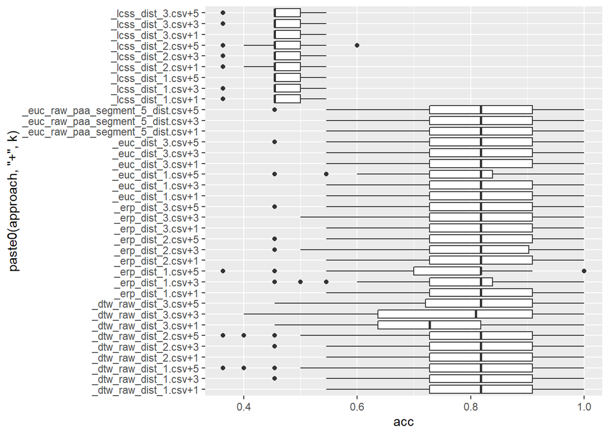

```r
ggplot(final_results,aes(x=paste0(approach,'+',k),y=acc))+geom_boxplot()+coord_flip()
```

Best result is from k=1, euc dist 3 value which is 0.834. It is from piecewise approximation aproach method.

## 4th Dataset Fish

## Data Manipulation

We read our data with fread function. We do some data manipulation to understand the data easier.

```r
fish_train=fread("D:/Boğaziçi/İe48b/Univariate_arff/Fish/Fish_TRAIN.txt")
fish_test=fread("D:/Boğaziçi/İe48b/Univariate_arff/Fish/Fish_TEST.txt")
head(fish_train,10)
```

```
##     V1       V2       V3       V4       V5       V6       V7       V8       V9
##  1:  7 1.950905 1.926654 1.895665 1.858015 1.820566 1.790278 1.767617 1.731273
##  2:  4 1.966652 1.940113 1.915149 1.945426 1.959289 1.945119 1.919668 1.881009
##  3:  6 2.005598 1.994541 1.987894 1.970090 1.939982 1.903903 1.864944 1.826148
##  4:  4 1.878433 1.871449 1.844617 1.811412 1.777580 1.742792 1.709533 1.677253
##  5:  7 1.987342 1.968160 1.942338 1.909628 1.872595 1.843493 1.810693 1.774459
##  6:  2 1.754350 1.716442 1.678512 1.640738 1.614897 1.577603 1.544358 1.507443
##  7:  2 1.828429 1.817876 1.788612 1.805830 1.815697 1.816147 1.786798 1.756889
##  8:  4 1.945563 1.929317 1.903194 1.864390 1.826540 1.789218 1.751275 1.712887
##  9:  7 1.990844 1.969546 1.950274 1.920670 1.880573 1.850206 1.820409 1.790786
## 10:  4 2.007074 1.987969 1.985472 1.961370 1.919717 1.878417 1.837477 1.796905
##          V10      V11      V12      V13      V14      V15      V16      V17
##  1: 1.695241 1.658904 1.622969 1.586888 1.557218 1.521723 1.486103 1.450451
##  2: 1.856474 1.818359 1.780485 1.742000 1.703821 1.666606 1.628375 1.591032
##  3: 1.787538 1.749095 1.710781 1.672604 1.634694 1.596742 1.558857 1.520917
```

[output cut: 766 more lines]

```r
head(fish_test,10)
```

```
##     V1       V2       V3       V4       V5       V6       V7       V8       V9
##  1:  5 2.034879 2.024707 1.981236 1.949717 1.910241 1.866555 1.823296 1.780061
##  2:  4 1.914966 1.906161 1.872251 1.840672 1.803525 1.772256 1.737121 1.704314
##  3:  2 1.911932 1.903034 1.879126 1.843910 1.817055 1.805468 1.763547 1.729432
##  4:  7 1.876776 1.864453 1.852517 1.847167 1.811883 1.779819 1.741805 1.703835
##  5:  1 1.760502 1.720664 1.681130 1.642338 1.604410 1.566267 1.527369 1.488610
##  6:  4 1.980282 1.958622 1.956446 1.928714 1.886998 1.844891 1.803300 1.761797
##  7:  7 1.959232 1.955929 1.932488 1.896188 1.860018 1.831048 1.807183 1.779124
##  8:  4 2.000112 1.981193 1.978328 1.938433 1.898257 1.857727 1.817838 1.793722
##  9:  5 1.697574 1.709380 1.716170 1.714310 1.700900 1.685841 1.662777 1.639941
## 10:  2 1.728279 1.697071 1.658751 1.620241 1.634546 1.661598 1.688792 1.683864
##          V10      V11      V12      V13      V14      V15      V16      V17
##  1: 1.737160 1.694562 1.652270 1.610030 1.567910 1.525847 1.483865 1.441944
##  2: 1.667985 1.636871 1.600202 1.563592 1.529448 1.490618 1.458085 1.424388
##  3: 1.687798 1.646508 1.605119 1.563302 1.522359 1.497672 1.472610 1.430236
```

[output cut: 766 more lines]

```r
setnames(fish_train,"V1","class")
fish_train=fish_train[order(class)]
fish_train[,class:=as.character(class)]
fish_train[,id:=1:.N]
long_fish_train=melt(fish_train,id.vars=c('id','class'))
long_fish_train[,time:=as.numeric(gsub("\\D", "", variable))]
long_fish_train=long_fish_train[,list(id,class,time,value)]
long_fish_train=long_fish_train[order(id,time)]
head(long_fish_train,20)
```

```
##     id class time    value
##  1:  1     1    2 1.977953
##  2:  1     1    3 1.963187
##  3:  1     1    4 1.934762
##  4:  1     1    5 1.897094
##  5:  1     1    6 1.859885
##  6:  1     1    7 1.816450
##  7:  1     1    8 1.773163
##  8:  1     1    9 1.730122
##  9:  1     1   10 1.687492
## 10:  1     1   11 1.644814
## 11:  1     1   12 1.602000
## 12:  1     1   13 1.559714
## 13:  1     1   14 1.517198
## 14:  1     1   15 1.474915
## 15:  1     1   16 1.432592
## 16:  1     1   17 1.390512
## 17:  1     1   18 1.348588
## 18:  1     1   19 1.306426
## 19:  1     1   20 1.264520
## 20:  1     1   21 1.222681
```

```r
long_fish_train
```

```
##         id class time    value
##     1:   1     1    2 1.977953
##     2:   1     1    3 1.963187
##     3:   1     1    4 1.934762
##     4:   1     1    5 1.897094
##     5:   1     1    6 1.859885
##    ---
## 81021: 175     7  460 1.841265
## 81022: 175     7  461 1.875700
## 81023: 175     7  462 1.917605
## 81024: 175     7  463 1.945344
## 81025: 175     7  464 1.955977
```

## Visualization

We use some plots to see our data and have some idea about the patterns.

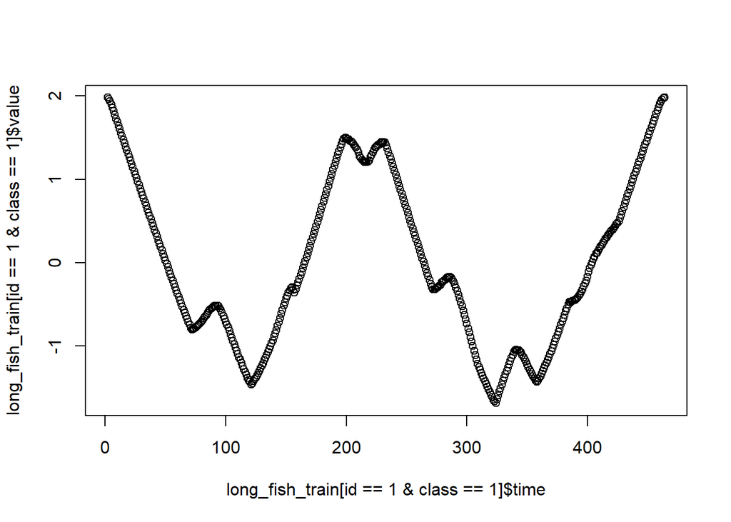

```r
plot(x=long_fish_train[id==1 & class==1]$time,y=long_fish_train[id==1 &  class==1]$value)
```

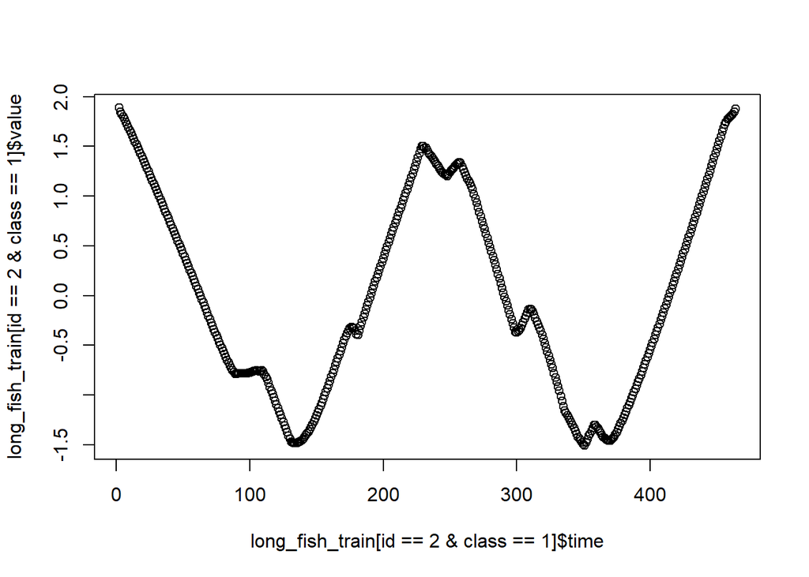

```r
plot(x=long_fish_train[id==2 & class==1]$time,y=long_fish_train[id==2 &  class==1]$value)
```

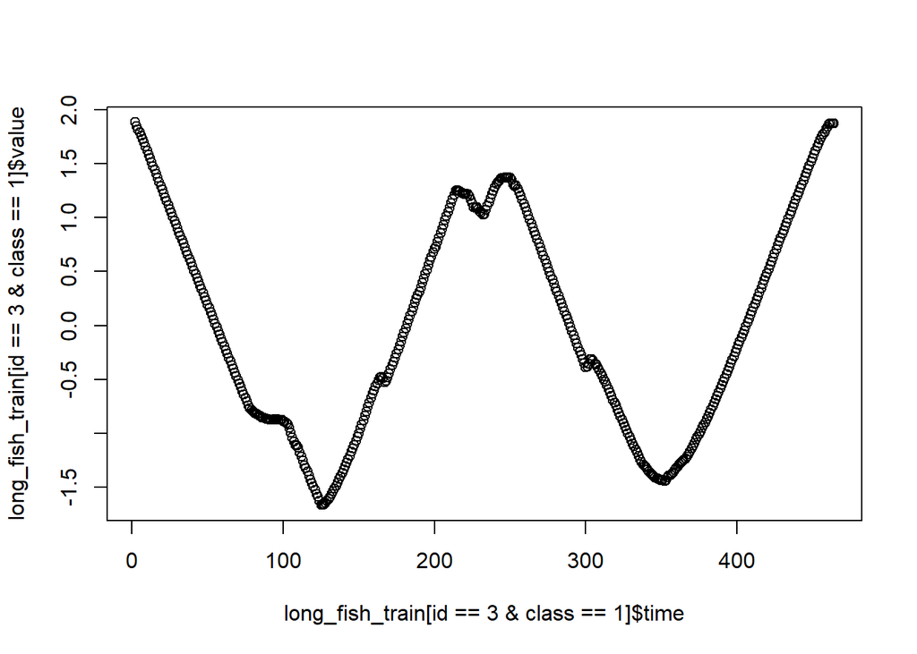

```r
plot(x=long_fish_train[id==3 & class==1]$time,y=long_fish_train[id==3 &  class==1]$value)
```

## Fused Lasso Approach

We will use fused lasso approach for one of our classification methods.

```r
train_row_4=nrow(fish_train)
test_row_4=nrow(fish_test)
f_res=vector("list",train_row_4)
for(i in 1:train_row_4){
      dt_4=long_fish_train[id==i]
      dt_4=as.matrix(dt_4[,4],rownames=FALSE)
      f_lasso=trendfilter(dt_4, ord=0)
      cv=cv.trendfilter(f_lasso)
      f_res[[i]]=predict.genlasso(f_lasso,cv$lambda.min)
}
```

[output not shown]

[output cut: 120 more lines]

[output not shown]

```r
fused_lasso_dt=vector('list',train_row_4)
for(i in seq(1:train_row_4)){
      fused_lasso_dt[[i]]=as.data.table(t(f_res[[i]]$fit))
}
lasso_fit=rbindlist(fused_lasso_dt)
head(lasso_fit,20)
```

```
##           V1       V2       V3       V4       V5       V6       V7       V8
##  1: 1.977354 1.963187 1.934762 1.897094 1.859885 1.816450 1.773163 1.730122
##  2: 1.886974 1.849757 1.824631 1.799098 1.776872 1.747330 1.719855 1.690626
##  3: 1.881024 1.848479 1.812753 1.790063 1.758131 1.723326 1.691993 1.654464
##  4: 1.814474 1.782895 1.744986 1.705631 1.674927 1.647592 1.695282 1.742102
##  5: 1.947089 1.929248 1.905736 1.867690 1.829844 1.792177 1.754741 1.717404
##  6: 1.657360 1.621217 1.582415 1.544099 1.505872 1.467470 1.429156 1.390732
##  7: 1.880353 1.871419 1.845574 1.807821 1.770217 1.732769 1.695353 1.657952
##  8: 1.786289 1.775092 1.750885 1.707583 1.676847 1.637896 1.594776 1.551431
##  9: 1.957512 1.927195 1.892574 1.864672 1.829363 1.790362 1.749427 1.708845
## 10: 1.886073 1.878648 1.873551 1.837032 1.800258 1.763726 1.724408 1.685244
## 11: 1.698718 1.666976 1.648105 1.607901 1.567726 1.527775 1.488054 1.448576
## 12: 1.669185 1.641176 1.598032 1.557630 1.517496 1.477376 1.437056 1.396587
## 13: 1.936056 1.927365 1.901854 1.867602 1.832555 1.798010 1.762778 1.728930
## 14: 2.003884 1.987070 1.970558 1.937246 1.898679 1.860377 1.822348 1.784599
```

[output cut: 1497 more lines]

## Piecewise Approximation Approach

We will use piecewise approximation approach for one of our classification methods.

```r
train_row_4=nrow(fish_train)
test_row_4=nrow(fish_test)
seg_len_1=5
long_trace_train=long_fish_train[order(id,time)]
paa_res=vector('list',train_row_4)
for (i in 1:train_row_4){
      data_ts=long_fish_train[id==i]$value
      paa_rep=repr_paa(data_ts,seg_len_1,meanC)
      paa_res[[i]]=paa_rep
}
paa_list=vector('list', train_row_4)
for (i in 1:train_row_4) {
      paa_list[[i]]=as.data.table(t(paa_res[[i]]))
}
paa_seg_5=rbindlist(paa_list)
head(paa_seg_5,20)
```

```
##           V1       V2        V3        V4        V5        V6        V7
##  1: 1.926576 1.730408 1.5172838 1.3065454 1.0971591 0.8895151 0.6835365
##  2: 1.827481 1.690552 1.5466887 1.3984813 1.2462486 1.0916588 0.9348969
##  3: 1.818093 1.654018 1.4760333 1.2938484 1.1134766 0.9350419 0.7578982
##  4: 1.744608 1.732528 1.7891547 1.6467479 1.4853703 1.3190604 1.1495553
##  5: 1.895935 1.718702 1.5392512 1.3627919 1.1862617 1.0121835 0.8421987
##  6: 1.582207 1.392349 1.4348422 1.6070953 1.5618184 1.3834939 1.2116271
##  7: 1.835137 1.658111 1.4726123 1.2880204 1.1032575 0.9201574 0.7376073
##  8: 1.739339 1.551457 1.3344965 1.3616749 1.5506587 1.6675603 1.4812989
##  9: 1.894270 1.709420 1.5066384 1.3015596 1.0944027 0.8860451 0.6788658
## 10: 1.855119 1.685385 1.4914860 1.3002389 1.1106860 0.9236981 0.7396850
## 11: 1.637926 1.448785 1.2539934 1.0623023 0.8727683 0.6852274 0.4997687
## 12: 1.596737 1.403854 1.4638392 1.6457949 1.6173687 1.4967324 1.3256459
## 13: 1.893116 1.728500 1.5552037 1.3784620 1.1998022 1.0203466 0.8397099
## 14: 1.959495 1.782802 1.5812697 1.3800581 1.1680248 0.9677142 0.7687739
```

[output cut: 300 more lines]

```r
seg_len_2=10
long_plane_train=long_fish_train[order(id,time)]
paa_res=vector('list',train_row_4)
for (i in 1:train_row_4){
      data_ts=long_fish_train[id==i]$value
      paa_rep=repr_paa(data_ts,seg_len_2,meanC)
      paa_res[[i]]=paa_rep
}
paa_list=vector('list', train_row_4)
for (i in 1:train_row_4) {
      paa_list[[i]]=as.data.table(t(paa_res[[i]]))
}
paa_seg_10=rbindlist(paa_list)
head(paa_seg_10,20)
```

```
##           V1        V2        V3          V4         V5           V6
##  1: 1.828492 1.4119146 0.9933371 0.579733902  0.1676618 -0.234172627
##  2: 1.759016 1.4725850 1.1689537 0.855502184  0.5349039  0.211032235
##  3: 1.736056 1.3849409 1.0242593 0.669647445  0.3177629 -0.033636613
##  4: 1.738568 1.7179513 1.4022153 1.066100841  0.7357851  0.400533113
##  5: 1.807318 1.4510215 1.0992226 0.758275832  0.4276930  0.101657876
##  6: 1.487278 1.5209687 1.4726562 1.126975369  0.7777523  0.424456106
##  7: 1.746624 1.3803164 1.0117074 0.646072256  0.2804089 -0.085303592
##  8: 1.645398 1.3480857 1.6091095 1.370857940  0.9315819  0.496114700
##  9: 1.801845 1.4040990 0.9902239 0.575269511  0.1588960 -0.253524786
## 10: 1.770252 1.3958624 1.0171920 0.649826692  0.2950390 -0.057034940
## 11: 1.543356 1.1581478 0.7789979 0.410047482  0.0535754 -0.298320121
## 12: 1.500296 1.5548170 1.5570505 1.237999920  0.8836222  0.519437564
## 13: 1.810808 1.4668329 1.1100744 0.748834752  0.3835318  0.015068834
## 14: 1.871148 1.4806639 1.0678695 0.669858031  0.2871026 -0.077477609
```

[output cut: 153 more lines]

```r
seg_len_3=20
long_plane_train=long_fish_train[order(id,time)]
paa_res=vector('list',train_row_4)
for (i in 1:train_row_4){
      data_ts=long_fish_train[id==i]$value
      paa_rep=repr_paa(data_ts,seg_len_3,meanC)
      paa_res[[i]]=paa_rep
}
paa_list=vector('list', train_row_4)
for (i in 1:train_row_4) {
      paa_list[[i]]=as.data.table(t(paa_res[[i]]))
}
paa_seg_20=rbindlist(paa_list)
head(paa_seg_20,20)
```

```
##           V1        V2          V3           V4         V5         V6
##  1: 1.620203 0.7865355 -0.03325540 -0.684876879 -0.5910152 -1.1389233
##  2: 1.615801 1.0122279  0.37296808 -0.284365754 -0.7512591 -0.8655798
##  3: 1.560498 0.8469534  0.14206314 -0.545675816 -0.8619222 -1.2063049
##  4: 1.728260 1.2341581  0.56815908 -0.124195417 -0.7991346 -1.0795863
##  5: 1.629170 0.9287492  0.26467544 -0.365333541 -0.7908089 -1.0227702
##  6: 1.504123 1.2998158  0.60110423 -0.094202937 -0.7476704 -1.1649271
##  7: 1.563470 0.8288898  0.09755267 -0.632935445 -1.1915768 -1.3554746
##  8: 1.496742 1.4899837  0.71384830 -0.145678614 -0.9703860 -1.4935544
##  9: 1.602972 0.7827467 -0.04731439 -0.743970146 -0.6227670 -1.0498720
## 10: 1.583057 0.8335094  0.11900204 -0.563132216 -1.0856996 -1.2766734
## 11: 1.350752 0.5945227 -0.12237236 -0.780705785 -0.9727383 -1.0398933
## 12: 1.527556 1.3975252  0.70152990 -0.005003422 -0.6290774 -0.8105884
## 13: 1.638820 0.9294546  0.19930033 -0.528561553 -0.9805729 -1.1001244
## 14: 1.675906 0.8688638  0.10481247 -0.572353951 -0.8728036 -0.9797640
```

[output cut: 69 more lines]

[figure not shown]

```r
plot(x=long_fish_train[id==1 & class==1]$time,y=long_fish_train[id==1 & class==1]$paa_seg_5)
```

[figure not shown]

```r
plot(x=long_fish_train[id==2 & class==1]$time,y=long_fish_train[id==2 & class==1]$paa_seg_10)
```

[figure not shown]

```r
plot(x=long_fish_train[id==3 & class==1]$time,y=long_fish_train[id==3 & class==1]$paa_seg_20)
```

```r
fish_train_raw=data.frame()
for(i in 1:length(unique(long_fish_train$id))){
    fish_train_raw=rbind(fish_train_raw,t(as.data.frame(long_fish_train[id==i]$value)))
}
row.names(fish_train_raw)=NULL
```

## Raw time series distances

```r
dataset='Fish'
main_path=sprintf('D:/Boğaziçi/İe48b/Univariate_arff/Trace/ClassificationData')
dist_path=sprintf('D:/Boğaziçi/İe48b/Univariate_arff/Trace/ClassificationData/distances')
large_number=10000

dist_euc_1=as.matrix(dist(fish_train_raw))
diag(dist_euc_1)=large_number
fwrite(dist_euc_1,sprintf('%s/_euc_dist_1.csv',dist_path),col.names=F)
```

```
## x being coerced from class: matrix to data.table
```

```r
dist_dtw_1=as.matrix(dtwDist(fish_train_raw))
diag(dist_dtw_1)=large_number
fwrite(dist_dtw_1,sprintf('%s/_dtw_raw_dist_1.csv',dist_path),col.names=F)
```

```
## x being coerced from class: matrix to data.table
```

```r
dist_lcss_1=TSDatabaseDistances(fish_train_raw,distance='lcss',epsilon=0.05)
dist_lcss_1=as.matrix(dist_lcss_1)
diag(dist_lcss_1)=large_number
fwrite(dist_lcss_1,sprintf('%s/_lcss_dist_1.csv',dist_path),col.names=F)
```

```
## x being coerced from class: matrix to data.table
```

```r
dist_erp_1=TSDatabaseDistances(fish_train_raw,distance='erp',g=0.5)
dist_erp_1=as.matrix(dist_erp_1)
diag(dist_erp_1)=large_number
fwrite(dist_erp_1,sprintf('%s/_erp_dist_1.csv', dist_path),col.names=F)
```

```
## x being coerced from class: matrix to data.table
```

## Fused Lasso Distances

```r
dist_euc_lasso=as.matrix(dist(lasso_fit))
diag(dist_euc_lasso)=large_number
fwrite(dist_euc_lasso,sprintf('%s_euc_lasso_dist.csv',dist_path),col.names=F)
```

```
## x being coerced from class: matrix to data.table
```

```r
dist_dtw_2=as.matrix(dtwDist(lasso_fit))
diag(dist_dtw_2)=large_number
fwrite(dist_dtw_2,sprintf('%s/_dtw_raw_dist_2.csv',dist_path),col.names=F)
```

```
## x being coerced from class: matrix to data.table
```

```r
dist_lcss_2=TSDatabaseDistances(lasso_fit,distance='lcss',epsilon=0.07)
dist_lcss_2=as.matrix(dist_lcss_2)
diag(dist_lcss_2)=large_number
fwrite(dist_lcss_2,sprintf('%s/_lcss_dist_2.csv',dist_path),col.names=F)
```

```
## x being coerced from class: matrix to data.table
```

```r
dist_erp_2=TSDatabaseDistances(lasso_fit,distance='erp',g=0.7)
dist_erp_2=as.matrix(dist_erp_2)
diag(dist_erp_2)=large_number
fwrite(dist_erp_2,sprintf('%s/_erp_dist_2.csv', dist_path),col.names=F)
```

```
## x being coerced from class: matrix to data.table
```

## Piecewise Approximation Approach distances

```r
dist_euc_paa=as.matrix(dist(paa_seg_5))
diag(dist_euc_paa)=large_number
fwrite(dist_euc_paa,sprintf('%s/_euc_raw_paa_segment_5_dist.csv',dist_path),col.names=F)
```

```
## x being coerced from class: matrix to data.table
```

```r
dist_euc_3=as.matrix(dist(paa_seg_5))
diag(dist_euc_3)=large_number
fwrite(dist_euc_3,sprintf('%s/_euc_dist_3.csv',dist_path),col.names=F)
```

```
## x being coerced from class: matrix to data.table
```

```r
dist_dtw_3=as.matrix(dtwDist(paa_seg_5))
diag(dist_dtw_3)=large_number
fwrite(dist_dtw_3,sprintf('%s/_dtw_raw_dist_3.csv',dist_path),col.names=F)
```

```
## x being coerced from class: matrix to data.table
```

```r
dist_lcss_3=TSDatabaseDistances(paa_seg_5,distance='lcss',epsilon=0.09)
dist_lcss_3=as.matrix(dist_lcss_3)
diag(dist_lcss_3)=large_number
fwrite(dist_lcss_3,sprintf('%s/_lcss_dist_3.csv',dist_path),col.names=F)
```

```
## x being coerced from class: matrix to data.table
```

```r
dist_erp_3=TSDatabaseDistances(paa_seg_5,distance='erp',g=0.9)
dist_erp_3=as.matrix(dist_erp_3)
diag(dist_erp_3)=large_number
fwrite(dist_erp_3,sprintf('%s/_erp_dist_3.csv', dist_path),col.names=F)
```

```
## x being coerced from class: matrix to data.table
```

```r
set.seed(213)
nof_rep=10
n_fold=10
trainclass=c()
for(i in 1:length(unique(long_fish_train$id))){
    trainclass=c(trainclass,unique(long_fish_train[id==i,class]))
}
cv_indices=generateCVRuns(trainclass,ntimes=nof_rep,nfold=n_fold,leaveOneOut=FALSE,stratified=TRUE)
str(cv_indices)
```

```
## List of 10
##  $ Run  1 :List of 10
##   ..$ Fold  1 : int [1:18] 24 23 8 49 36 27 71 68 88 96 ...
##   ..$ Fold  2 : int [1:18] 12 13 14 34 39 79 69 52 94 85 ...
##   ..$ Fold  3 : int [1:18] 16 5 4 28 48 65 59 67 100 89 ...
##   ..$ Fold  4 : int [1:18] 9 15 19 38 35 70 64 75 81 95 ...
##   ..$ Fold  5 : int [1:18] 1 25 22 50 43 57 55 76 86 91 ...
##   ..$ Fold  6 : int [1:17] 2 21 10 30 33 73 77 61 90 93 ...
##   ..$ Fold  7 : int [1:17] 26 7 29 41 51 60 72 56 83 97 ...
##   ..$ Fold  8 : int [1:17] 3 18 32 42 44 58 54 53 84 80 ...
##   ..$ Fold  9 : int [1:17] 20 6 46 31 37 66 74 62 82 99 ...
##   ..$ Fold  10: int [1:17] 11 17 40 47 45 78 63 98 87 92 ...
##  $ Run  2 :List of 10
##   ..$ Fold  1 : int [1:18] 21 14 23 27 30 38 53 52 87 90 ...
##   ..$ Fold  2 : int [1:18] 6 3 15 34 45 59 55 62 100 89 ...
##   ..$ Fold  3 : int [1:18] 11 18 1 51 50 67 76 60 84 85 ...
##   ..$ Fold  4 : int [1:18] 7 8 9 44 43 65 72 71 94 88 ...
##   ..$ Fold  5 : int [1:18] 16 19 26 28 37 74 77 61 96 91 ...
##   ..$ Fold  6 : int [1:17] 2 20 5 48 47 70 58 75 98 97 ...
##   ..$ Fold  7 : int [1:17] 12 17 31 33 40 66 79 68 83 81 ...
##   ..$ Fold  8 : int [1:17] 22 13 36 41 35 69 57 63 86 99 ...
##   ..$ Fold  9 : int [1:17] 4 10 29 39 49 54 64 73 92 82 ...
##   ..$ Fold  10: int [1:17] 25 24 46 32 42 56 78 95 93 80 ...
##  $ Run  3 :List of 10
##   ..$ Fold  1 : int [1:18] 20 11 7 51 38 48 57 77 94 97 ...
##   ..$ Fold  2 : int [1:18] 2 8 24 41 44 79 64 73 90 86 ...
##   ..$ Fold  3 : int [1:18] 1 4 19 43 45 74 54 67 98 95 ...
##   ..$ Fold  4 : int [1:18] 16 21 12 30 31 69 58 63 91 84 ...
##   ..$ Fold  5 : int [1:18] 17 25 9 34 37 53 71 61 96 82 ...
##   ..$ Fold  6 : int [1:17] 6 13 14 29 42 65 56 60 92 80 ...
##   ..$ Fold  7 : int [1:17] 18 5 36 50 28 76 75 55 93 88 ...
##   ..$ Fold  8 : int [1:17] 10 3 40 49 39 78 66 70 99 87 ...
##   ..$ Fold  9 : int [1:17] 26 23 27 32 35 72 59 68 100 81 ...
##   ..$ Fold  10: int [1:17] 15 22 47 33 46 52 62 85 89 83 ...
##  $ Run  4 :List of 10
##   ..$ Fold  1 : int [1:18] 10 21 12 49 37 36 54 55 82 98 ...
##   ..$ Fold  2 : int [1:18] 16 2 17 48 44 77 64 72 96 91 ...
##   ..$ Fold  3 : int [1:18] 23 25 3 27 51 67 53 59 86 93 ...
##   ..$ Fold  4 : int [1:18] 26 5 14 30 35 61 56 71 95 83 ...
##   ..$ Fold  5 : int [1:18] 11 7 18 38 34 62 60 78 97 84 ...
```

[output cut: 56 more lines]

```
##   ..$ Fold  7 : int [1:17] 10 1 51 35 33 69 78 53 94 98 ...
##   ..$ Fold  8 : int [1:17] 2 6 34 27 30 61 65 59 86 84 ...
##   ..$ Fold  9 : int [1:17] 9 12 46 41 40 52 72 56 80 81 ...
##   ..$ Fold  10: int [1:17] 18 15 44 39 37 54 63 96 90 95 ...
##  $ Run  10:List of 10
##   ..$ Fold  1 : int [1:18] 9 21 20 47 29 48 68 57 86 96 ...
##   ..$ Fold  2 : int [1:18] 11 23 16 42 40 64 75 60 98 84 ...
##   ..$ Fold  3 : int [1:18] 8 4 2 46 51 78 59 56 97 92 ...
##   ..$ Fold  4 : int [1:18] 18 24 3 44 39 79 58 77 81 88 ...
##   ..$ Fold  5 : int [1:18] 10 12 15 50 27 76 52 70 83 100 ...
##   ..$ Fold  6 : int [1:17] 6 13 5 32 36 61 55 69 93 90 ...
##   ..$ Fold  7 : int [1:17] 26 25 31 45 37 62 73 63 91 99 ...
##   ..$ Fold  8 : int [1:17] 1 17 49 41 35 67 71 74 85 82 ...
##   ..$ Fold  9 : int [1:17] 22 19 38 28 34 65 53 66 80 94 ...
##   ..$ Fold  10: int [1:17] 7 14 43 33 30 72 54 95 89 87 ...
```

```r
dist_folder=sprintf('D:/Boğaziçi/İe48b/Univariate_arff/Trace/ClassificationData/distances')
dist_files=list.files(dist_folder, full.names=T)
```

```r
k_levels=c(1,3,5)
approach_file=list.files(dist_folder)
result=vector('list',length(dist_files)*nof_rep*n_fold*length(k_levels))
iter=1
for(m in 1:length(dist_files)){ #
    dist_mat=as.matrix(fread(dist_files[m],header=FALSE))
    for(i in 1:nof_rep){
        this_fold=cv_indices[[i]]
        for(j in 1:n_fold){
            test_indices=this_fold[[j]]
            for(k in 1:length(k_levels)){
                current_k=k_levels[k]
                current_fold=nn_classify_cv(dist_mat,trainclass,test_indices,k=current_k)
                accuracy=sum(trainclass[test_indices]==current_fold$prediction$predicted)/length(test_indices)
                tmp=data.table(approach=approach_file[m],repid=i,foldid=j,
                               k=current_k,acc=accuracy)
                result[[iter]]=tmp
                iter=iter+1

            }

        }

    }

}
```

```r
final_results=rbindlist(result)
summarized_results=final_results[,list(avg_acc=mean(acc),sdev_acc=sd(acc),result_count=.N),by=list(approach,k)]
summarized_results[order(-avg_acc)]
```

```
##                            approach k    avg_acc   sdev_acc result_count
##  1:                 _erp_dist_3.csv 5 0.56816993 0.09097716          100
##  2:                 _erp_dist_3.csv 3 0.55607843 0.10176109          100
##  3:                 _erp_dist_2.csv 5 0.54709150 0.09722500          100
##  4:                 _erp_dist_2.csv 3 0.54705882 0.09286307          100
##  5:                 _erp_dist_1.csv 5 0.54447712 0.09174568          100
##  6:                 _erp_dist_1.csv 3 0.54075163 0.09269617          100
##  7:                 _erp_dist_3.csv 1 0.53702614 0.11737446          100
##  8:             _dtw_raw_dist_1.csv 3 0.53101307 0.09925795          100
##  9:             _dtw_raw_dist_2.csv 3 0.53042484 0.09944167          100
## 10:             _dtw_raw_dist_1.csv 5 0.52967320 0.09983682          100
## 11:             _dtw_raw_dist_2.csv 5 0.52686275 0.09955213          100
## 12:                 _erp_dist_2.csv 1 0.52133987 0.10722514          100
## 13:             _dtw_raw_dist_1.csv 1 0.51647059 0.10440370          100
## 14:             _dtw_raw_dist_2.csv 1 0.51366013 0.10577253          100
```

[output cut: 23 more lines]

```r
overall_results_summary=final_results[,list(avg_acc=mean(acc),sdev_acc=sd(acc),result_count=.N),by=list(approach,k)]
overall_results_summary[which.max(overall_results_summary$avg_acc),]
```

```
##           approach k   avg_acc   sdev_acc result_count
## 1: _erp_dist_3.csv 5 0.5681699 0.09097716          100
```

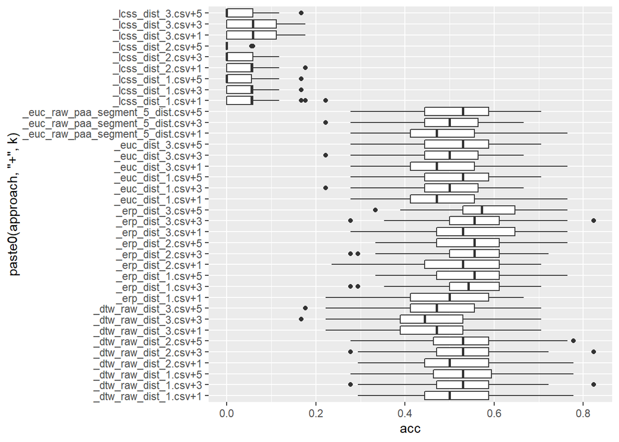

```r
ggplot(final_results,aes(x=paste0(approach,'+',k),y=acc))+geom_boxplot()+coord_flip()
```

Best result is from k=5, erp dist 3 value which is 0.568. It is from piecewise aprroximation method.

## 5th Dataset ECG200

## Data Manipulation

We read our data with fread function. We do some data manipulation to understand the data easier.

```r
ECG200_train=fread("D:/Boğaziçi/İe48b/Univariate_arff/ECG200/ECG200_TRAIN.txt")
ECG200_test=fread("D:/Boğaziçi/İe48b/Univariate_arff/ECG200/ECG200_TEST.txt")
head(ECG200_train,10)
```

```
##     V1        V2        V3        V4        V5         V6         V7
##  1: -1 0.5020555 0.5421626 0.7223835 1.4288852 2.13651580  2.2811490
##  2:  1 0.1476469 0.8046684 0.3677715 0.2438937 0.02661388 -0.2744021
##  3: -1 0.3166462 0.2431991 0.3704714 1.0637381 1.67818710  1.7595575
##  4: -1 1.1688741 2.0759008 1.7601405 1.6064459 1.94904560  1.3028421
##  5:  1 0.6486575 0.7520260 2.6362312 3.4557156 2.11815740  0.5206202
##  6:  1 0.4047327 1.2808587 2.5151479 1.2995187 1.45343230  0.4742751
##  7: -1 1.2050062 2.0318554 2.4472937 2.7394479 2.74588990  2.2763553
##  8: -1 0.5982414 1.0987288 1.6835287 2.4789134 2.80241270  2.4386960
##  9:  1 0.3280083 1.2102222 2.5976534 2.2107785 1.62166640 -0.2393211
## 10:  1 1.6682060 2.8481734 2.5169776 2.1727729 0.72046706  0.7253757
##              V8         V9         V10         V11         V12        V13
##  1:  1.93627370  1.4688900  1.00884510  0.38028224 -0.29677967 -0.5139287
##  2:  0.09673058 -0.7477306 -1.60977710 -1.17959310 -1.05592640 -1.1287774
##  3:  1.69771720  1.6121590  1.16818770  0.49995704 -0.02236253 -0.2353182
```

[output cut: 161 more lines]

```r
head(ECG200_test,10)
```

```
##     V1        V2        V3        V4       V5         V6         V7         V8
##  1:  1 0.4251894 1.4185988 2.6687913 3.298629  2.2645539  0.1651795 -0.9597265
##  2:  1 0.6539293 2.1772899 3.6447828 2.279203  0.9783674 -0.3882958 -0.9119111
##  3:  1 0.4049532 0.5539960 0.7240971 1.449039  2.0126163  1.6244769  1.2047262
##  4:  1 1.0880883 2.0119486 2.3017332 1.630199  0.6367680 -0.1405017  0.5479535
##  5: -1 0.4436209 0.9472850 1.9240844 2.159790  1.4994468  0.9645078  0.2232562
##  6:  1 0.2094264 1.2733286 2.8243142 3.592306  2.2236616  0.5703741 -0.9387727
##  7:  1 1.0850983 1.8537059 1.8341764 1.550000  1.3830018  1.0015947  0.2553477
##  8:  1 1.7092211 2.7528523 1.6829902 1.241862 -0.0379721 -0.2175889  0.7896456
##  9:  1 1.6243869 2.9533979 2.6974247 2.697235  1.0675545  0.2103698  1.1575930
## 10: -1 0.7956747 0.9502404 1.1466679 1.749125  2.4258016  2.6709641  2.4624665
##             V9         V10         V11         V12         V13         V14
##  1:  0.2826684  0.84285041  0.68345828  1.08208790  0.72257693  0.10981136
##  2: -0.1483295  0.30543881 -0.23009793 -0.45153026  0.22411262 -0.55005370
##  3:  1.1175109  0.56209949 -0.01155647 -0.15105966 -0.16572346 -0.14970342
```

[output cut: 161 more lines]

```r
setnames(ECG200_train,"V1","class")
ECG200_train=ECG200_train[order(class)]
ECG200_train[,class:=as.character(class)]
ECG200_train[,id:=1:.N]
long_ECG200_train=melt(ECG200_train,id.vars=c('id','class'))
long_ECG200_train[,time:=as.numeric(gsub("\\D", "", variable))]
long_ECG200_train=long_ECG200_train[,list(id,class,time,value)]
long_ECG200_train=long_ECG200_train[order(id,time)]
head(long_ECG200_train,20)
```

```
##     id class time      value
##  1:  1    -1    2  0.5020555
##  2:  1    -1    3  0.5421626
##  3:  1    -1    4  0.7223835
##  4:  1    -1    5  1.4288852
##  5:  1    -1    6  2.1365158
##  6:  1    -1    7  2.2811490
##  7:  1    -1    8  1.9362737
##  8:  1    -1    9  1.4688900
##  9:  1    -1   10  1.0088451
## 10:  1    -1   11  0.3802822
## 11:  1    -1   12 -0.2967797
## 12:  1    -1   13 -0.5139287
## 13:  1    -1   14 -0.2556447
## 14:  1    -1   15 -0.1072025
## 15:  1    -1   16 -0.2878266
## 16:  1    -1   17 -0.4180090
## 17:  1    -1   18 -0.3191631
## 18:  1    -1   19 -0.2603787
## 19:  1    -1   20 -0.3503572
## 20:  1    -1   21 -0.5054860
```

```r
long_ECG200_train
```

```
##        id class time       value
##    1:   1    -1    2  0.50205548
##    2:   1    -1    3  0.54216265
##    3:   1    -1    4  0.72238348
##    4:   1    -1    5  1.42888520
##    5:   1    -1    6  2.13651580
##   ---
## 9596: 100     1   93 -0.34763359
## 9597: 100     1   94 -0.44744306
## 9598: 100     1   95 -0.06668896
## 9599: 100     1   96 -0.17844792
## 9600: 100     1   97 -0.25605159
```

## Fused Lasso Approach

We will use fused lasso approach for one of our classification methods.

```r
train_row_5=nrow(ECG200_train)
test_row_5=nrow(ECG200_train)
f_res=vector("list",train_row_5)
for(i in 1:train_row_5){
      dt_5=long_ECG200_train[id==i]
      dt_5=as.matrix(dt_5[,4],rownames=FALSE)
      f_lasso=trendfilter(dt_5, ord=0)
      cv=cv.trendfilter(f_lasso)
      f_res[[i]]=predict.genlasso(f_lasso,cv$lambda.min)
}
```

[output not shown]

[output cut: 45 more lines]

[output not shown]

```r
fused_lasso_dt=vector('list',train_row_5)
for(i in seq(1:train_row_5)){
      fused_lasso_dt[[i]]=as.data.table(t(f_res[[i]]$fit))
}
lasso_fit=rbindlist(fused_lasso_dt)
head(lasso_fit,20)
```

```
##             V1         V2         V3         V4          V5          V6
##  1:  0.5029490  0.5421626  0.7223835  1.4288852  2.13651580  2.27936187
##  2:  0.3138179  0.2488557  0.3704714  1.0637381  1.67818710  1.75390091
##  3:  1.1695894  2.0744703  1.7601405  1.6078764  1.94761506  1.30284210
##  4:  1.2068665  2.0318554  2.4472937  2.7394479  2.74216939  2.27635530
##  5:  0.6009172  1.0987288  1.6835287  2.4789134  2.79706098  2.43869600
##  6:  0.5034890  0.7291306  0.8337402  1.2557705  2.00136160  2.49930126
##  7:  1.0881132  1.5639665  1.3688902  1.2502307  1.49149820  1.68251571
##  8:  0.5267555  1.0079024  1.7898944  2.3573271  2.30147370  2.08702460
##  9:  1.3741046  2.7792648  2.6405387  1.2185972 -0.01065915  1.15086983
## 10:  0.2038361  0.4620785  0.7483677  0.9969592  0.99695917  0.85108707
## 11:  2.0406177  2.0215905  1.9272558  2.3330001  1.17387370 -0.45254768
## 12:  0.3142400  0.7810625  1.2049684  1.5346969  1.87733140  2.15817268
## 13:  0.7621166  1.2370342  1.8886928  1.4324433  0.78670067 -0.41137918
## 14:  1.4689830  3.2539464  3.5983793  2.3933767  0.41850771  1.07145400
```

[output cut: 342 more lines]

## Piecewise Approximation Approach

We will use piecewise approximation approach for one of our classification methods.

```r
train_row_5=nrow(ECG200_train)
test_row_5=nrow(ECG200_test)
seg_len_1=5
long_ECG200_train=long_ECG200_train[order(id,time)]
paa_res=vector('list',train_row_5)
for (i in 1:train_row_5){
      data_ts=long_ECG200_train[id==i]$value
      paa_rep=repr_paa(data_ts,seg_len_1,meanC)
      paa_res[[i]]=paa_rep
}
paa_list=vector('list', train_row_5)
for (i in 1:train_row_5) {
      paa_list[[i]]=as.data.table(t(paa_res[[i]]))
}
paa_seg_5=rbindlist(paa_list)
head(paa_seg_5,20)
```

```
##             V1         V2           V3          V4          V5         V6
##  1:  1.0664005  1.4150880 -0.292276426 -0.37067881 -0.96365775 -1.1896584
##  2:  0.7344484  1.3475157 -0.153993400 -0.42961784 -0.93881920 -1.3082628
##  3:  1.7120814  0.8239985  0.660243824 -0.15212011 -0.27344018 -1.0023200
##  4:  2.2338986  0.9443428 -0.195458492 -0.42124600 -0.82207352 -0.7241534
##  5:  1.7323650  1.0402908 -0.179893567 -0.45779342 -0.95844906 -1.6062455
##  6:  1.0642252  2.2435029  0.469702746  0.07343792 -0.05705454 -0.4606550
##  7:  1.3525324  0.4377745 -1.080506526 -1.32241978 -1.37576882 -1.5223872
##  8:  1.5967393  1.2868979 -0.176284918 -0.35549803 -0.72572670 -1.1293185
##  9:  1.5957610  0.4899013 -1.421414860 -1.86172642 -1.83859078 -0.8628715
## 10:  0.6817994  0.7407687 -0.432240556 -0.62968372 -0.77633157 -0.8090310
## 11:  1.8994036 -0.9189883 -1.517852100 -1.78701964 -1.90249664 -1.0371168
## 12:  1.1424558  1.5594619 -0.144715338 -0.08294528 -0.68490790 -0.9356603
## 13:  1.2434730 -0.6802372 -1.206447842 -1.58635250 -2.28810456 -1.6529130
## 14:  2.2265255  1.4142433 -0.483884416 -1.12455190 -1.64078318 -1.9571293
```

[output cut: 69 more lines]

```r
seg_len_2=10
long_ECG200_train=long_ECG200_train[order(id,time)]
paa_res=vector('list',train_row_5)
for (i in 1:train_row_5){
      data_ts=long_ECG200_train[id==i]$value
      paa_rep=repr_paa(data_ts,seg_len_2,meanC)
      paa_res[[i]]=paa_rep
}
paa_list=vector('list', train_row_5)
for (i in 1:train_row_5) {
      paa_list[[i]]=as.data.table(t(paa_res[[i]]))
}
paa_seg_10=rbindlist(paa_list)
head(paa_seg_10,20)
```

```
##             V1         V2         V3           V4          V5            V6
##  1:  1.2407443 -0.3314776 -1.0766581 -1.724199720 -0.99082654  0.3600780540
##  2:  1.0409820 -0.2918056 -1.1235410 -1.842886370 -0.85046662  0.5059372130
##  3:  1.2680399  0.2540619 -0.6378801 -1.654593860 -1.29796823  0.1716952332
##  4:  1.5891207 -0.3083522 -0.7731135 -1.436916954 -1.27684915  0.1658583659
##  5:  1.3863279 -0.3188435 -1.2823473 -1.789471210 -0.04157795  0.5024160420
##  6:  1.6538641  0.2715703 -0.2588547 -1.081396204 -1.68208500 -0.6930169957
##  7:  0.8951535 -1.2014632 -1.4490780 -1.177649417  0.11884865  0.3038375280
##  8:  1.4418186 -0.2658915 -0.9275226 -1.724682540 -0.98994846  0.1777644849
##  9:  1.0428311 -1.6415706 -1.3507311  1.251392025  0.62648986  0.1486090798
## 10:  0.7112840 -0.5309621 -0.7926813 -0.939956358 -1.33289603 -0.0251776709
## 11:  0.4902076 -1.6524359 -1.4698067  0.679320699  0.53601446  0.6557504030
## 12:  1.3509588 -0.1138303 -0.8102841 -1.585921320 -1.37800134  0.0009176763
## 13:  0.2816179 -1.3964002 -1.9705088 -0.049399378  0.53510521  0.7223520980
## 14:  1.8203844 -0.8042182 -1.7989563 -0.009125244  0.59145323  0.1900495431
```

[output cut: 27 more lines]

```r
seg_len_3=20
long_ECG200_train=long_ECG200_train[order(id,time)]
paa_res=vector('list',train_row_5)
for (i in 1:train_row_5){
      data_ts=long_ECG200_train[id==i]$value
      paa_rep=repr_paa(data_ts,seg_len_3,meanC)
      paa_res[[i]]=paa_rep
}
paa_list=vector('list', train_row_5)
for (i in 1:train_row_5) {
      paa_list[[i]]=as.data.table(t(paa_res[[i]]))
}
paa_seg_20=rbindlist(paa_list)
head(paa_seg_20,20)
```

```
##              V1          V2         V3         V4          V5
##  1:  0.45463332 -1.40042890 -0.3153742 0.66280414  0.74795711
##  2:  0.37458821 -1.48321370 -0.1722647 0.75262256  0.66033453
##  3:  0.76105090 -1.14623697 -0.5631365 0.27849941  0.83727893
##  4:  0.64038423 -1.10501521 -0.5554954 0.55567769  0.58056085
##  5:  0.53374219 -1.53590925  0.2304190 0.59139018  0.22544730
##  6:  0.96271720 -0.67012548 -1.1875510 0.46754032  0.53427370
##  7: -0.15315485 -1.31336372  0.2113431 0.55614758  0.87378486
##  8:  0.58796355 -1.32610257 -0.4060920 0.48726615  0.82120607
##  9: -0.29936975 -0.04966955  0.3875495 0.01485357 -0.06670469
## 10:  0.09016095 -0.86631882 -0.6790368 0.39813238  1.32132792
## 11: -0.58111411 -0.39524302  0.5958824 0.14243422  0.29755059
## 12:  0.61856426 -1.19810271 -0.6885418 0.70237236  0.70713491
## 13: -0.55739112 -1.00995408  0.6287287 0.57943086  0.44898213
## 14:  0.50808313 -0.90404075  0.3907514 0.05815694 -0.06618837
## 15:  0.61735686 -0.96288364 -0.6430520 0.13269700  1.06985226
## 16: -0.16612753 -0.78525684  0.3084773 0.29980123  0.42888224
## 17: -0.71276569 -1.36457008  0.3908354 0.87709147  1.01176109
## 18: -0.41851096 -0.47200272  0.6435697 0.01329312  0.29206355
## 19:  0.51621220 -1.09863512 -0.7515447 0.75238219  0.72698184
## 20:  0.20707180 -0.58357433  0.1810253 0.09546578  0.12501426
```

```r
ECG200_train_raw=data.frame()
for(i in 1:length(unique(long_ECG200_train$id))){
    plane_train_raw=rbind(ECG200_train_raw,t(as.data.frame(long_ECG200_train[id==i]$value)))
}
row.names(ECG200_train_raw)=NULL
```

## Raw time series distances

```r
dataset='ECG200'
main_path=sprintf('D:/Boğaziçi/İe48b/Univariate_arff/ECG200/ClassificationData')
dist_path=sprintf('D:/Boğaziçi/İe48b/Univariate_arff/ECG200/ClassificationData/distances')
large_number=10000

dist_euc_1=as.matrix(dist(ECG200_test))
diag(dist_euc_1)=large_number
fwrite(dist_euc_1,sprintf('%s/_euc_dist_1.csv',dist_path),col.names=F)
```

```
## x being coerced from class: matrix to data.table
```

```r
dist_dtw_1=as.matrix(dtwDist(ECG200_test))
diag(dist_dtw_1)=large_number
fwrite(dist_dtw_1,sprintf('%s/_dtw_raw_dist_1.csv',dist_path),col.names=F)
```

```
## x being coerced from class: matrix to data.table
```

```r
dist_lcss_1=TSDatabaseDistances(ECG200_test,distance='lcss',epsilon=0.05)
dist_lcss_1=as.matrix(dist_lcss_1)
diag(dist_lcss_1)=large_number
fwrite(dist_lcss_1,sprintf('%s/_lcss_dist_1.csv',dist_path),col.names=F)
```

```
## x being coerced from class: matrix to data.table
```

```r
dist_erp_1=TSDatabaseDistances(ECG200_test,distance='erp',g=0.5)
dist_erp_1=as.matrix(dist_erp_1)
diag(dist_erp_1)=large_number
fwrite(dist_erp_1,sprintf('%s/_erp_dist_1.csv', dist_path),col.names=F)
```

```
## x being coerced from class: matrix to data.table
```

## Fused Lasso Distances

```r
dist_euc_lasso=as.matrix(dist(lasso_fit))
diag(dist_euc_lasso)=large_number
fwrite(dist_euc_lasso,sprintf('%s_euc_lasso_dist.csv',dist_path),col.names=F)
```

```
## x being coerced from class: matrix to data.table
```

```r
dist_dtw_2=as.matrix(dtwDist(lasso_fit))
diag(dist_dtw_2)=large_number
fwrite(dist_dtw_2,sprintf('%s/_dtw_raw_dist_2.csv',dist_path),col.names=F)
```

```
## x being coerced from class: matrix to data.table
```

```r
dist_lcss_2=TSDatabaseDistances(lasso_fit,distance='lcss',epsilon=0.07)
dist_lcss_2=as.matrix(dist_lcss_2)
diag(dist_lcss_2)=large_number
fwrite(dist_lcss_2,sprintf('%s/_lcss_dist_2.csv',dist_path),col.names=F)
```

```
## x being coerced from class: matrix to data.table
```

```r
dist_erp_2=TSDatabaseDistances(lasso_fit,distance='erp',g=0.7)
dist_erp_2=as.matrix(dist_erp_2)
diag(dist_erp_2)=large_number
fwrite(dist_erp_2,sprintf('%s/_erp_dist_2.csv', dist_path),col.names=F)
```

```
## x being coerced from class: matrix to data.table
```

## Piecewise Approximation Approach distances

```r
dist_euc_paa=as.matrix(dist(paa_seg_5))
diag(dist_euc_paa)=large_number
fwrite(dist_euc_paa,sprintf('%s/_euc_raw_paa_segment_5_dist.csv',dist_path),col.names=F)
```

```
## x being coerced from class: matrix to data.table
```

```r
dist_euc_3=as.matrix(dist(paa_seg_5))
diag(dist_euc_3)=large_number
fwrite(dist_euc_3,sprintf('%s/_euc_dist_3.csv',dist_path),col.names=F)
```

```
## x being coerced from class: matrix to data.table
```

```r
dist_dtw_3=as.matrix(dtwDist(paa_seg_5))
diag(dist_dtw_3)=large_number
fwrite(dist_dtw_3,sprintf('%s/_dtw_raw_dist_3.csv',dist_path),col.names=F)
```

```
## x being coerced from class: matrix to data.table
```

```r
dist_lcss_3=TSDatabaseDistances(paa_seg_5,distance='lcss',epsilon=0.09)
dist_lcss_3=as.matrix(dist_lcss_3)
diag(dist_lcss_3)=large_number
fwrite(dist_lcss_3,sprintf('%s/_lcss_dist_3.csv',dist_path),col.names=F)
```

```
## x being coerced from class: matrix to data.table
```

```r
dist_erp_3=TSDatabaseDistances(paa_seg_5,distance='erp',g=0.9)
dist_erp_3=as.matrix(dist_erp_3)
diag(dist_erp_3)=large_number
fwrite(dist_erp_3,sprintf('%s/_erp_dist_3.csv', dist_path),col.names=F)
```

```
## x being coerced from class: matrix to data.table
```

```r
set.seed(213)
nof_rep=10
n_fold=10
trainclass=c()
for(i in 1:length(unique(long_ECG200_train$id))){
    trainclass=c(trainclass,unique(long_ECG200_train[id==i,class]))
}
cv_indices=generateCVRuns(trainclass,ntimes=nof_rep,nfold=n_fold,leaveOneOut=FALSE,stratified=TRUE)
str(cv_indices)
```

```
## List of 10
##  $ Run  1 :List of 10
##   ..$ Fold  1 : int [1:10] 24 19 20 15 73 87 58 80 59 48
##   ..$ Fold  2 : int [1:10] 12 11 30 97 36 50 53 100 75 79
##   ..$ Fold  3 : int [1:10] 16 13 26 43 96 37 86 64 52 41
##   ..$ Fold  4 : int [1:10] 9 18 6 81 89 72 60 67 33 47
##   ..$ Fold  5 : int [1:10] 1 22 17 69 77 57 95 65 56 99
##   ..$ Fold  6 : int [1:10] 23 7 4 51 85 82 45 54 62 84
##   ..$ Fold  7 : int [1:10] 2 28 8 94 39 46 74 92 71 78
##   ..$ Fold  8 : int [1:10] 29 14 25 83 66 88 40 76 90 32
##   ..$ Fold  9 : int [1:10] 3 10 27 68 35 98 44 61 34 91
##   ..$ Fold  10: int [1:10] 31 5 21 55 38 49 42 70 93 63
##  $ Run  2 :List of 10
##   ..$ Fold  1 : int [1:10] 24 27 3 25 68 71 88 60 64 91
##   ..$ Fold  2 : int [1:10] 11 31 10 75 40 98 92 74 80 51
##   ..$ Fold  3 : int [1:10] 28 4 26 83 46 70 79 44 72 76
##   ..$ Fold  4 : int [1:10] 8 13 29 36 50 89 61 90 63 82
##   ..$ Fold  5 : int [1:10] 16 18 21 99 81 93 84 69 73 47
##   ..$ Fold  6 : int [1:10] 20 5 22 43 87 95 66 48 100 94
##   ..$ Fold  7 : int [1:10] 1 9 2 56 54 57 53 35 33 77
##   ..$ Fold  8 : int [1:10] 23 30 6 67 62 49 34 32 96 59
##   ..$ Fold  9 : int [1:10] 19 17 7 45 97 78 42 55 41 86
##   ..$ Fold  10: int [1:10] 15 12 14 38 39 37 58 52 65 85
##  $ Run  3 :List of 10
##   ..$ Fold  1 : int [1:10] 12 1 4 31 46 80 68 57 95 72
##   ..$ Fold  2 : int [1:10] 11 8 19 71 34 63 93 64 54 89
##   ..$ Fold  3 : int [1:10] 13 25 24 45 77 32 94 33 36 53
##   ..$ Fold  4 : int [1:10] 17 18 28 78 38 58 81 100 79 73
##   ..$ Fold  5 : int [1:10] 22 26 30 49 55 41 75 37 56 96
##   ..$ Fold  6 : int [1:10] 2 27 21 65 69 52 35 51 87 99
##   ..$ Fold  7 : int [1:10] 5 7 14 50 60 88 59 98 44 82
##   ..$ Fold  8 : int [1:10] 10 15 9 92 39 90 43 76 86 48
##   ..$ Fold  9 : int [1:10] 3 29 23 62 66 84 70 83 74 40
##   ..$ Fold  10: int [1:10] 20 6 16 67 91 47 85 42 61 97
##  $ Run  4 :List of 10
##   ..$ Fold  1 : int [1:10] 10 15 29 7 87 75 58 84 54 99
##   ..$ Fold  2 : int [1:10] 2 17 18 55 65 95 48 69 46 94
##   ..$ Fold  3 : int [1:10] 16 4 23 38 74 45 80 78 71 57
##   ..$ Fold  4 : int [1:10] 22 6 12 67 56 82 49 96 76 64
##   ..$ Fold  5 : int [1:10] 19 20 14 32 100 33 35 40 73 81
```

[output cut: 56 more lines]

```
##   ..$ Fold  7 : int [1:10] 9 24 30 49 99 89 61 96 65 93
##   ..$ Fold  8 : int [1:10] 28 27 16 70 40 86 54 47 84 100
##   ..$ Fold  9 : int [1:10] 12 10 17 53 95 85 37 68 76 55
##   ..$ Fold  10: int [1:10] 23 4 29 52 64 58 97 35 38 34
##  $ Run  10:List of 10
##   ..$ Fold  1 : int [1:10] 21 12 27 29 49 96 94 47 83 95
##   ..$ Fold  2 : int [1:10] 4 14 1 76 93 42 91 71 52 73
##   ..$ Fold  3 : int [1:10] 16 20 6 46 82 44 78 51 80 64
##   ..$ Fold  4 : int [1:10] 2 26 31 59 77 48 58 85 53 62
##   ..$ Fold  5 : int [1:10] 17 9 10 89 36 67 97 66 74 41
##   ..$ Fold  6 : int [1:10] 5 24 30 45 60 63 84 55 69 54
##   ..$ Fold  7 : int [1:10] 13 18 25 92 56 57 86 32 88 38
##   ..$ Fold  8 : int [1:10] 7 15 11 70 43 34 68 61 75 37
##   ..$ Fold  9 : int [1:10] 22 8 28 33 87 99 81 100 50 40
##   ..$ Fold  10: int [1:10] 23 3 19 39 98 79 65 35 72 90
```

```r
dist_folder=sprintf('D:/Boğaziçi/İe48b/Univariate_arff/ECG200/ClassificationData/distances')
dist_files=list.files(dist_folder, full.names=T)
```

```r
k_levels=c(1,3,5)
approach_file=list.files(dist_folder)
result=vector('list',length(dist_files)*nof_rep*n_fold*length(k_levels))
iter=1
for(m in 1:length(dist_files)){ #
    dist_mat=as.matrix(fread(dist_files[m],header=FALSE))
    for(i in 1:nof_rep){
        this_fold=cv_indices[[i]]
        for(j in 1:n_fold){
            test_indices=this_fold[[j]]
            for(k in 1:length(k_levels)){
                current_k=k_levels[k]
                current_fold=nn_classify_cv(dist_mat,trainclass,test_indices,k=current_k)
                accuracy=sum(trainclass[test_indices]==current_fold$prediction$predicted)/length(test_indices)
                tmp=data.table(approach=approach_file[m],repid=i,foldid=j,
                               k=current_k,acc=accuracy)
                result[[iter]]=tmp
                iter=iter+1

            }

        }

    }

}
```

```r
final_results=rbindlist(result)
summarized_results=final_results[,list(avg_acc=mean(acc),sdev_acc=sd(acc),result_count=.N),by=list(approach,k)]
summarized_results[order(-avg_acc)]
```

```
##                            approach k avg_acc   sdev_acc result_count
##  1:                 _euc_dist_3.csv 3   0.855 0.10766108          100
##  2: _euc_raw_paa_segment_5_dist.csv 3   0.855 0.10766108          100
##  3:                 _euc_dist_3.csv 5   0.823 0.10904081          100
##  4: _euc_raw_paa_segment_5_dist.csv 5   0.823 0.10904081          100
##  5:                 _erp_dist_2.csv 3   0.805 0.10766108          100
##  6:                 _erp_dist_2.csv 5   0.805 0.11403969          100
##  7:                 _erp_dist_3.csv 3   0.804 0.12137262          100
##  8:                 _euc_dist_3.csv 1   0.800 0.12472191          100
##  9: _euc_raw_paa_segment_5_dist.csv 1   0.800 0.12472191          100
## 10:                 _erp_dist_2.csv 1   0.798 0.11368928          100
## 11:                 _erp_dist_3.csv 1   0.791 0.12956415          100
## 12:                 _erp_dist_3.csv 5   0.785 0.12502525          100
## 13:             _dtw_raw_dist_2.csv 3   0.774 0.11066375          100
## 14:             _dtw_raw_dist_3.csv 3   0.771 0.12168431          100
```

[output cut: 23 more lines]

```r
overall_results_summary=final_results[,list(avg_acc=mean(acc),sdev_acc=sd(acc),result_count=.N),by=list(approach,k)]
overall_results_summary[which.max(overall_results_summary$avg_acc),]
```

```
##           approach k avg_acc  sdev_acc result_count
## 1: _euc_dist_3.csv 3   0.855 0.1076611          100
```

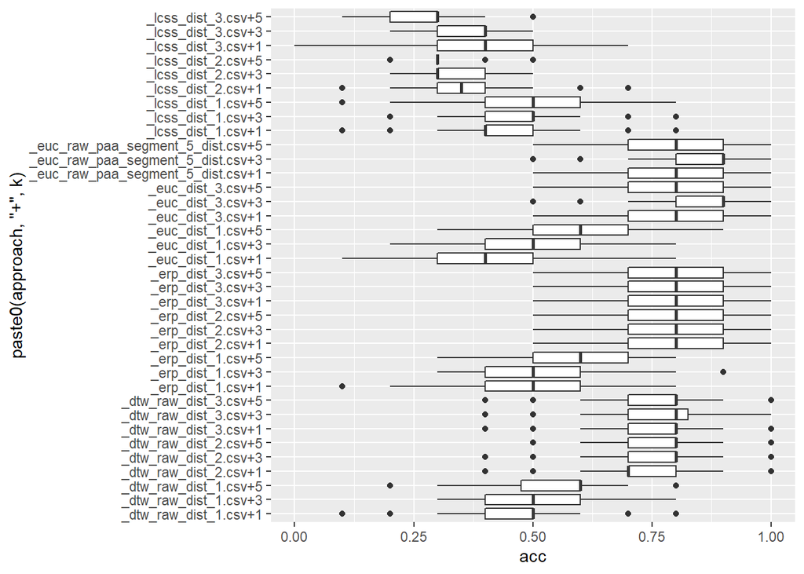

```r
ggplot(final_results,aes(x=paste0(approach,'+',k),y=acc))+geom_boxplot()+coord_flip()
```

## Conclusion

5 datasets are inspected. In the first one raw time series distances gave the best accuracy. In the second one raw time series distances gave the best accuracy.In the third one piecewise approximation method distances gave the best accuracy. In the fourth one piecewise approximation method distances gave the best accuracy.In the fifth one piecewise approximation method distances gave the best accuracy. We can say that piecewise approximation method gives better accuracy in calculation. Standard deviation accuracies are approximately 0.1 in all datasets.